Return to main page

# Predicting house prices for Ames, Iowa

The Ames house pricing dataset is a useful dataset for applying regression models. A goal is to, given a set of features describing a house, predict the price a house would sell for. Kaggle run a 'competition' with this dataset for this purpose: https://www.kaggle.com/c/house-prices-advanced-regression-techniques/overview.

While the below is my own work, I took some inspiration and ideas from several analyses others have performed. Below are a few examples from other authors I found useful.

- https://www.kaggle.com/pmarcelino/comprehensive-data-exploration-with-python
- https://lstrln.wordpress.com/2017/09/13/predicting-house-prices-on-kaggle-a-gentle-introduction-to-data-science-part-i/
- https://www.kaggle.com/mgmarques/houses-prices-complete-solution/comments#notebook-container

**TODO:** While the below is an end-to-end analysis and set of prediction models, there are a few things which I could do to improve the score I achieved. My thought process as I was working on this project was that 'perfect is the enemy of good'. My submission is, as of writing this, good enough to be in roughly the top 40% of submissions on Kaggle. While I could spend time on the following points, they would likely only gain a small improvement in my score. In a business setting, where a 0.1% improvement may be worth substantial money, it would be worth spending the time on the following. However, at this point I'm not terribly interested in going up a few places on the Kaggle leaderboard! I'd rather focus on one or more novel projects with more practical use. I will not rule out coming back to try a few of these! Here is a list of additional things I could do.

- Some additional feature engineering - there are 79 explanatory variables in the input dataset, many with strong correlation to the response so there is not a massive need for this. However, some housing-related variables could be quite simple to implement. Similarly, transformations of existing variables might be worth exploring (including polynomials)
- Experimentation with outliers - there are a few outlier points, though my quick analysis suggested they should not be too influential. However, it might be worth going back and performing a more robust analysis and manipulation of them.
- Gradient boosting - it looks like a lot of Kaggle submissions for this challenge (and many others!) make keen use of algorithms such as XGBoost. For now I have chosen to stick with linear models, but I am aware there may be good alternatives.
- Model stacking - similarly, I could look into combining the results of models to improve the score. I haven't done this as I appreciate being able to interpret the model (through, for example, examining regression coefficients).

If I have time I might try a few of these.

# Setup

```python
from copy import deepcopy
from IPython.display import display

import pandas as pd
import numpy as np
import matplotlib.pyplot as plt
import seaborn as sns
from scipy.stats import norm
```

```python
pd.options.display.max_columns = None
%matplotlib inline
```

```python
initial_train = pd.read_csv(r'data\input\train.csv')
initial_test = pd.read_csv(r'data\input\test.csv')
```

# Exploratory data analysis

Before applying machine learning algorithms I'm keen to understand the data a bit better. While doing so, I can apply and data cleaning or pre-processing techniques which will likely improve model fit and generalisability.

## Data structure

```python
print("Shape of train dataframe: " + str(initial_train.shape))
print("Number of distinct Id values: " + str(initial_train.Id.nunique()))
```

```
Shape of train dataframe: (1460, 81)
Number of distinct Id values: 1460
```

The are 1460 observations with a target called 'SalePrice' and a unique 'Id' variable which can be dropped.

```python
initial_train.drop('Id', axis=1, inplace=True)
initial_train.head()
```

|  | MSSubClass | MSZoning | LotFrontage | LotArea | Street | Alley | LotShape | LandContour | Utilities | LotConfig | LandSlope | Neighborhood | Condition1 | Condition2 | BldgType | HouseStyle | OverallQual | OverallCond | YearBuilt | YearRemodAdd | RoofStyle | RoofMatl | Exterior1st | Exterior2nd | MasVnrType | MasVnrArea | ExterQual | ExterCond | Foundation | … |
| --- | --- | --- | --- | --- | --- | --- | --- | --- | --- | --- | --- | --- | --- | --- | --- | --- | --- | --- | --- | --- | --- | --- | --- | --- | --- | --- | --- | --- | --- | --- |
| 0 | 60 | RL | 65.0 | 8450 | Pave | NaN | Reg | Lvl | AllPub | Inside | Gtl | CollgCr | Norm | Norm | 1Fam | 2Story | 7 | 5 | 2003 | 2003 | Gable | CompShg | VinylSd | VinylSd | BrkFace | 196.0 | Gd | TA | PConc | … |
| 1 | 20 | RL | 80.0 | 9600 | Pave | NaN | Reg | Lvl | AllPub | FR2 | Gtl | Veenker | Feedr | Norm | 1Fam | 1Story | 6 | 8 | 1976 | 1976 | Gable | CompShg | MetalSd | MetalSd | None | 0.0 | TA | TA | CBlock | … |
| 2 | 60 | RL | 68.0 | 11250 | Pave | NaN | IR1 | Lvl | AllPub | Inside | Gtl | CollgCr | Norm | Norm | 1Fam | 2Story | 7 | 5 | 2001 | 2002 | Gable | CompShg | VinylSd | VinylSd | BrkFace | 162.0 | Gd | TA | PConc | … |
| 3 | 70 | RL | 60.0 | 9550 | Pave | NaN | IR1 | Lvl | AllPub | Corner | Gtl | Crawfor | Norm | Norm | 1Fam | 2Story | 7 | 5 | 1915 | 1970 | Gable | CompShg | Wd Sdng | Wd Shng | None | 0.0 | TA | TA | BrkTil | … |
| 4 | 60 | RL | 84.0 | 14260 | Pave | NaN | IR1 | Lvl | AllPub | FR2 | Gtl | NoRidge | Norm | Norm | 1Fam | 2Story | 8 | 5 | 2000 | 2000 | Gable | CompShg | VinylSd | VinylSd | BrkFace | 350.0 | Gd | TA | PConc | … |

This is what the first few rows show us. While there are too many variables to go through at this stage, we can see there are a range of variables with missing values, as well as numerous categorical variables (as can be seen in the accompanying data_description.txt file).

```python
col_types = initial_train.dtypes
col_types.groupby(col_types).size()
```

```
int64      34
float64     3
object     43
dtype: int64
```

A reasonable number of our features (36 excepting the target variable 'SalesPrice') are numerical, however 43 are not.

### Missing values overview

```python
missing_values = initial_train.isnull().mean()
missing_values[(missing_values.index.isin(col_types[col_types==object].index)) & (missing_values>0)].sort_values(ascending=False)
```

```
PoolQC          0.995205
MiscFeature     0.963014
Alley           0.937671
Fence           0.807534
FireplaceQu     0.472603
GarageCond      0.055479
GarageQual      0.055479
GarageFinish    0.055479
GarageType      0.055479
BsmtFinType2    0.026027
BsmtExposure    0.026027
BsmtFinType1    0.025342
BsmtCond        0.025342
BsmtQual        0.025342
MasVnrType      0.005479
Electrical      0.000685
dtype: float64
```

```python
missing_values[(missing_values.index.isin(col_types[col_types!=object].index)) & (missing_values>0)].sort_values(ascending=False)
```

```
LotFrontage    0.177397
GarageYrBlt    0.055479
MasVnrArea     0.005479
dtype: float64
```

There are 19 variables with missing values, only three of which are numeric. Most of them only have a small (less than 5% or so) percentage missing, whilst there are several others such as `PoolQC` with the vast majority missing.

- Note that there appear to be three groups of variables which have missing values for their group's other variables when one of the group's variables is missing. These are related to the garage, basement, and masonary. However, the former two have multiple other variables in their group which have no missing values (e.g. `BsmtFinSF1` and `BsmtFinSF2`, and `GarageCars` and `GarageArea`); we may be able to impute using this.
- There is a similar story for `FireplaceQu` (`Fireplaces`) and `PoolQC` (`PoolArea`) which have many missing values. Again we may be able to somewhat reliably impute using these, especially as large percentages of each are missing
- `MiscFeature` is mostly missing. There is a category for 'none', but less than 4% have any of the five other specified categories so we'd likely need to assume these missing values also represent 'none'
- `LotFrontage` also has a non-negligible number of missing entries. However, we may be able to see if there is a relationship with `LotArea`, `LotConfig`, and `LotShape` which we may be able to use to model to estimate the missing values.
- `Alley` is less clear; like `MiscFeature` this may just be a case of setting them as 'NA'
- `Fence` is similar to `Alley`
- `Electrical` has less than 0.1% missing, or one observation, meaning it would be best to either drop this observation or use the average value

Now we understand the structure of our data a bit better, we can start looking at individual variables, and attempt to look at their individual distributions and correlations.

## Dependent variable 'SalePrice'

It makes sense to start with the target variable.

```python
print(col_types['SalePrice'])
```

```
int64
```

As expected (this is a regression problem!), we have numerical response variable.

```python
initial_train['SalePrice'].describe()
```

```
count      1460.000000
mean     180921.195890
std       79442.502883
min       34900.000000
25%      129975.000000
50%      163000.000000
75%      214000.000000
max      755000.000000
Name: SalePrice, dtype: float64
```

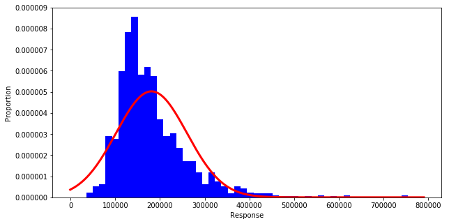

```python
mean, std = norm.fit(initial_train['SalePrice'])

fig = plt.figure(figsize=(10, 5))
#initial_train['SalePrice'].hist(bins=50)
plt.hist(initial_train['SalePrice'], color='b', bins=50, density=True)
lim_xmin, lim_xmax = plt.xlim()
xvals = np.linspace(lim_xmin, lim_xmax, 200)
plt.plot(xvals, norm.pdf(xvals, mean, std), color='r', linewidth=3)
plt.xlabel('Response')
plt.ylabel('Proportion')
plt.show()
```

This is definitely not normal (-ly distributed)! We might want to look into performing a log transformation on this a bit later as we may otherwise have issues with linearity.

## Modifying the data and feature engineering

### Dependent variable

One of the key assumptions of regression is that the distribution of errors is normal. Though not essential, it is also beneficial that the dependent variable is normal as it reduces the chances of other regression assumptions being violated (including linearity).

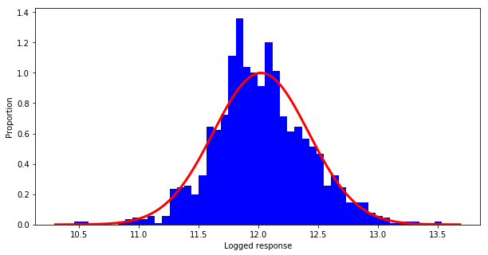

```python
initial_train['LogSalePrice'] = np.log(initial_train['SalePrice'])

# Get theoretical normal distribution from mean and standard deviation of the data
mean, std = norm.fit(initial_train['LogSalePrice'])

fig = plt.figure(figsize=(10, 5))
plt.hist(initial_train['LogSalePrice'], color='b', bins=50, density=True)
lim_xmin, lim_xmax = plt.xlim()
xvals = np.linspace(lim_xmin, lim_xmax, 200)
plt.plot(xvals, norm.pdf(xvals, mean, std), color='r', linewidth=3)
plt.xlabel('Logged response')
plt.ylabel('Proportion')
plt.show()
```

This is much closer to a normal distribution. As a result, we will consider this as our new dependent variable as we can do the inverse transform (exponentiation) to get the price back in terms of dollars. At this point I will also drop the original `SalePrice` variable so we don't accidentally include it in our model.

```python
initial_train.drop(columns='SalePrice', inplace=True)
```

### Variables types

```python
cols_numeric = list(initial_train.select_dtypes(include=np.number).columns)
cols_cat = list(initial_train.select_dtypes(include=object).columns)

print("Number of numeric features: {}".format(len(cols_numeric) - 1))
print("Number of categorical (non-numeric) features: {}".format(len(cols_cat)))
```

```
Number of numeric features: 36
Number of categorical (non-numeric) features: 43
```

There are a mix of numeric and categorical features. However, before proceding it is worth checking whether any numeric variables are really categories encoded as numbers. Similarly, I will look for ordinal features in the numeric list to keep an eye on.

A reminder of the numeric columns:

```python
print(cols_numeric)
```

```
['MSSubClass', 'LotFrontage', 'LotArea', 'OverallQual', 'OverallCond', 'YearBuilt', 'YearRemodAdd', 'MasVnrArea', 'BsmtFinSF1', 'BsmtFinSF2', 'BsmtUnfSF', 'TotalBsmtSF', '1stFlrSF', '2ndFlrSF', 'LowQualFinSF', 'GrLivArea', 'BsmtFullBath', 'BsmtHalfBath', 'FullBath', 'HalfBath', 'BedroomAbvGr', 'Kitc…
```

According to the accompanying data description, `MSSubClass` should be considered a categorical variable as the numeric encodings are not appropriately ordered. The various year variables may also be categorical for this reason, as is the `MoSold`.

Ordinal features include `OverallQual`, `OverallCond` in the numeric variables. For the categorical variables, `Utilities` (potentially), `LandSlope` (though this may quite easily be non-linear as potentially a medium slope may be preferable to buyers), `ExterQual`, `ExterCond`, `HeatingQC`, `KitchenQual`, and `PavedDrive` could be considered or mapped to be ordinal (none of these include N/A or missing entries such as `BsmtFinType1`). The other categorical variables should be considered as such and will need to be dealt with appropriately whereas those above may be mapped to numeric variables to reduce dimensionality. Note a couple of the other categorical variables are binary.

```python
cols_cat += ['MSSubClass', 'YearBuilt', 'YearRemodAdd', 'GarageYrBlt', 'YrSold', 'MoSold']
cols_numeric.remove('MSSubClass')
cols_numeric.remove('MoSold')
cols_numeric = [col for col in cols_numeric if col not in ['MSSubClass', 'YearBuilt', 'YearRemodAdd', 'GarageYrBlt', 'YrSold']]
print("Number of numeric features: {}".format(len(cols_numeric) - 1))
print("Number of categorical (non-numeric) features: {}".format(len(cols_cat)))
```

```
Number of numeric features: 30
Number of categorical (non-numeric) features: 49
```

### Categorical features

I will start with categorical features.

```python
print(cols_cat)
```

```
['MSZoning', 'Street', 'Alley', 'LotShape', 'LandContour', 'Utilities', 'LotConfig', 'LandSlope', 'Neighborhood', 'Condition1', 'Condition2', 'BldgType', 'HouseStyle', 'RoofStyle', 'RoofMatl', 'Exterior1st', 'Exterior2nd', 'MasVnrType', 'ExterQual', 'ExterCond', 'Foundation', 'BsmtQual', 'BsmtCond',…
```

First let's investigate each values of each categorical variable in terms of its relationship with the response.

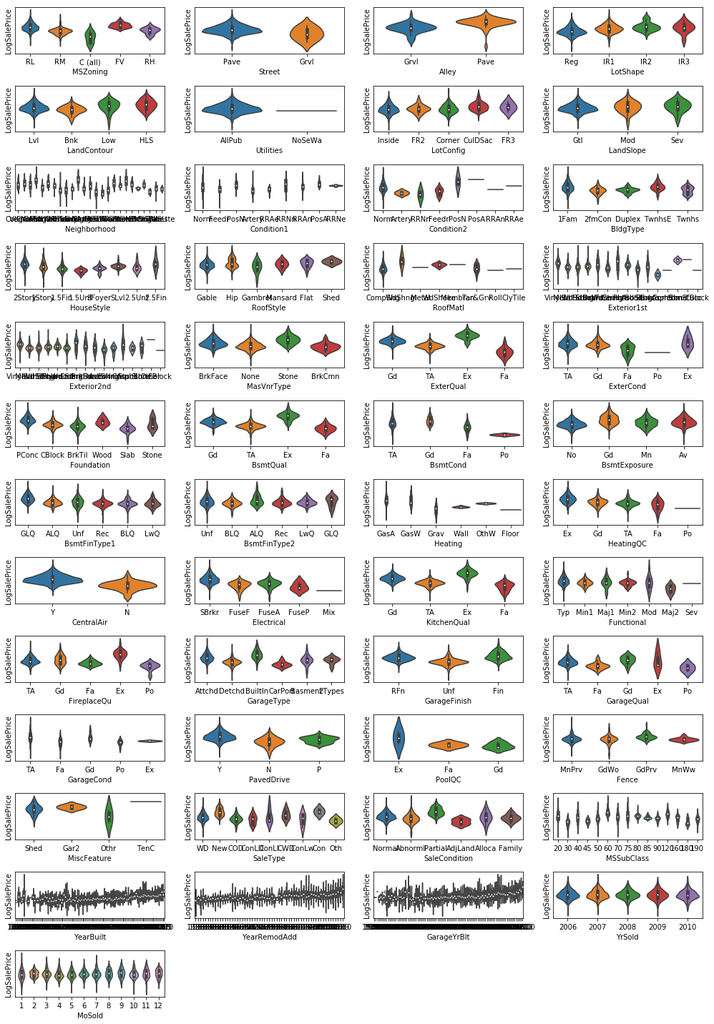

```python
n_cols = 4
n_rows = int(np.ceil(len(cols_cat) / n_cols))
fig, ax = plt.subplots(n_rows, n_cols, figsize=(14, 20))

for a in ax.ravel():
     a.set_yticks([])

# Create a violinplot for each categorical variable and its relationship with the response
id_row = 0
id_col = 0
for i, sp in enumerate(cols_cat):

    sns.violinplot(x=sp, y='LogSalePrice', data=initial_train, ax=ax[id_row, id_col])

    # update row and column count
    if id_col == n_cols - 1:
        id_row += 1
        id_col = 0
    else:
        id_col += 1

# Remove any axes for unneeded subplots
for k in np.arange(i - 1, n_rows * n_cols - 2):

    fig.delaxes(ax[id_row, id_col])

    # update row and column count
    if id_col == n_cols - 1:
        id_row += 1
        id_col = 0
    else:
        id_col += 1

plt.tight_layout()
plt.show()
```

There is a lot to digest from this. I will try to unpack this below. The above plot, while full-on, is useful to get a quick understanding of each categorical variable. If there were many more it would become too difficult to read and I would have to think further how to display this.

- **Suggested ordinal variables**: `Utilities` , `LandSlope`, `ExterQual`, `ExterCond`, `HeatingQC`, `KitchenQual`, and `PavedDrive` were mentioned as possibly being able to be converted to a numeric variable due to possible ordinalities (their values containing Excellent, Good, etc.). From the plots, we can see that `Utilities` only has two of its possible four values suggested by the data description in the training set - we need to bear this in mind as they may appear in the test set. We cannot tell from this whether this would be a good ordinal feature (or even a good feature at all!). `LandSlope`, `ExterQual`, `ExterCond`, `HeatingQC`, `KitchenQual`, and `PavedDrive` all appear to be resonable candidates for ordinal features.
- **Years**: The year variables generally appear to have a small upward trend - the newer the house/garage, or remodelling the larger the price. For this reason, I will switch these back to be numeric. The year sold variable does not adhere to this trend, albeit there are fewer years.
- **Month**: The `MoSold` variable may be cyclic in nature (though it is hard to tell from this plot). Therefore I will reconvert it to a numeric column by turning it into cyclic features (i.e. the cos and sin of it).
- **Utilities**: This appears to only have very few values in the non-dominant level so I will remove it.
- **Other features**: Some, but not all, of the other features appear to have reasonable correlation with the response, though many of their values spreads are quite large. `Neighborhood` for example looks to be useful.

A couple of the features may potentially be able to be considered as random effects due to their clustered nature. I would say the main two candidates are year (based upon its fairly high cardinality), and neighbourhood (as one might imagine location might have a strong impact on price).

```python
initial_train.drop(columns='Utilities', inplace=True)
initial_test.drop(columns='Utilities', inplace=True)
```

```python
cols_numeric += ['YearBuilt', 'YearRemodAdd', 'GarageYrBlt', 'MoSold']
cols_cat = [col for col in cols_cat if col not in ['YearBuilt', 'YearRemodAdd', 'GarageYrBlt', 'MoSold', 'Utilities']]
print("Number of numeric features: {}".format(len(cols_numeric) - 1))
print("Number of categorical (non-numeric) features: {}".format(len(cols_cat)))
```

```
Number of numeric features: 34
Number of categorical (non-numeric) features: 44
```

#### Collapsing categories

Some categorical variables have few values for one or more of their categories, as can be seen in the above plot. This will mean that if we later encode these variables, there may be features which are more or less redundant. As a result, our models may suffer from having too high a dimensionality in terms of input features.

An easy fix is, when performing the one hot encoding, to look for columns with a low number of ones in, and simply drop them from the resultant data set. An alternative would be to either assign levels with low values to be a different level. This would be difficult to do in a data driven way as we do not know what we can map these categories to. We could map these levels to the closest level with enough occurrences (based on the closest mean sale price for the levels), but with such low numbers this would be inaccurate. Similarly, we could group the low occurrence levels together, though there is no guarantee they will be related in any way! I will do the ohe column dropping shortly after the encoding itself is performed.

```python
min_threshold = 10

for sp in cols_cat:
    vcounts = initial_train[sp].value_counts()
    troublesome = vcounts[vcounts < min_threshold]
    if len(troublesome) > 0:
        print('\n============== ' + sp + ' ==============')
        for vci, vcv in troublesome.iteritems():
            print(str(vci) + ': ' + str(vcv))
```

```
============== Street ==============
Grvl: 6

============== LotConfig ==============
FR3: 4

============== Neighborhood ==============
NPkVill: 9
Blueste: 2

============== Condition1 ==============
PosA: 8
RRNn: 5
RRNe: 2

============== Condition2 ==============
Feedr: 6
Artery: 2
PosN: 2
RRNn: 2
RRAn: 1
PosA: 1
RRAe: 1

============== HouseStyle ==============
2.5Fin: 8

============== RoofStyle ==============
Mansard: 7
Shed: 2

============== RoofMatl ==============
WdShngl: 6
WdShake: 5
Membran: 1
ClyTile: 1
Roll: 1
Metal: 1

============== Exterior1st ==============
```

[output cut: 62 more lines]

```
TenC: 1

============== SaleType ==============
ConLD: 9
ConLI: 5
ConLw: 5
CWD: 4
Oth: 3
Con: 2

============== SaleCondition ==============
AdjLand: 4

============== MSSubClass ==============
40: 4
```

#### Dealing with missing values

As shown earlier we have missing valiues for several categorical variables. I will deal with them here for both training and test datasets.

```python
missing_values_train = initial_train.isnull().sum()
print("Missing in training set:\n" + str(missing_values_train[(missing_values_train.index.isin(col_types[col_types==object].index)) &
                     (missing_values_train>0)].sort_values(ascending=False)))

print("-" * 30)
missing_values_test = initial_test.isnull().sum()
print("Missing in test set:\n" + str(missing_values_test[(missing_values_test.index.isin(col_types[col_types==object].index)) &
                     (missing_values_test>0)].sort_values(ascending=False)))
```

```
Missing in training set:
PoolQC          1453
MiscFeature     1406
Alley           1369
Fence           1179
FireplaceQu      690
GarageCond        81
GarageQual        81
GarageFinish      81
GarageType        81
BsmtFinType2      38
BsmtExposure      38
BsmtFinType1      37
BsmtCond          37
BsmtQual          37
MasVnrType         8
Electrical         1
dtype: int64
------------------------------
Missing in test set:
PoolQC          1456
MiscFeature     1408
Alley           1352
Fence           1169
FireplaceQu      730
GarageCond        78
GarageQual        78
GarageFinish      78
GarageType        76
BsmtCond          45
BsmtQual          44
BsmtExposure      44
BsmtFinType2      42
BsmtFinType1      42
MasVnrType        16
MSZoning           4
Functional         2
Exterior1st        1
SaleType           1
Exterior2nd        1
KitchenQual        1
dtype: int64
```

##### PoolQC

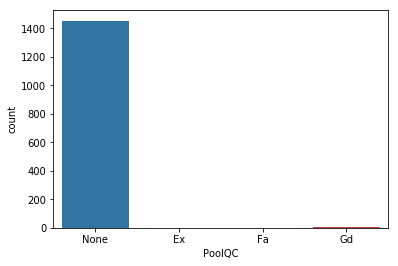

```python
sns.countplot(x='PoolQC', data=initial_train.fillna('None'))
```

The overwhelming majority of properties have no pool, so it makes sense to drop this variable (and the corresponding `PoolArea`).

```python
initial_train.drop(columns=['PoolQC', 'PoolArea'], inplace=True)
initial_test.drop(columns=['PoolQC', 'PoolArea'], inplace=True)
```

##### MiscFeature

Here I will simply create a replacement variable with value 1 if the property has a misc feature and 0 otherwise. This is because the plot above suggests (other than potentially the 'other' value), this leads to a somewhat inflated price. We also have the problem that the vast majority are missing otherwise.

```python
initial_train['HasMiscFeature'] = np.where(initial_train['MiscFeature'].isna(), 0, 1)
initial_test['HasMiscFeature'] = np.where(initial_test['MiscFeature'].isna(), 0, 1)
initial_train.drop(columns=['MiscFeature'], inplace=True)
initial_test.drop(columns=['MiscFeature'], inplace=True)
```

##### Alley:

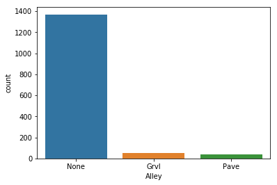

```python
sns.countplot(x='Alley', data=initial_train.fillna('None'))
plt.show()
```

I will simply replace the missings with another category ('none'). Note though that the are few alleys so this approach may potentially lead to some overfitting. Otherwise I could do what I did for `MiscFeature`.

```python
initial_train['Alley'].fillna('None', inplace=True)
initial_test['Alley'].fillna('None', inplace=True)
```

##### Fence:

I will simply do what I did for `MiscFeature`.

```python
initial_train['HasFence'] = np.where(initial_train['Fence'].isna(), 0, 1)
initial_test['HasFence'] = np.where(initial_test['Fence'].isna(), 0, 1)
initial_train.drop(columns=['Fence'], inplace=True)
initial_test.drop(columns=['Fence'], inplace=True)
```

##### FireplaceQu

I will again set missings to be a new category of 'None'.

```python
initial_train['FireplaceQu'].fillna('None', inplace=True)
initial_test['FireplaceQu'].fillna('None', inplace=True)
```

##### Basement and garage variables

I will assume missing values means the property doesn't have these, hence I will set a new value for none for each of the related variables.

```python
initial_train['GarageType'].fillna('None', inplace=True)
initial_train['GarageFinish'].fillna('None', inplace=True)
initial_train['GarageQual'].fillna('None', inplace=True)
initial_train['GarageCond'].fillna('None', inplace=True)
initial_test['GarageType'].fillna('None', inplace=True)
initial_test['GarageFinish'].fillna('None', inplace=True)
initial_test['GarageQual'].fillna('None', inplace=True)
initial_test['GarageCond'].fillna('None', inplace=True)
# Remove this as it was changed back to numeric but still has missing values
initial_train.drop(columns=['GarageYrBlt'], inplace=True)
initial_test.drop(columns=['GarageYrBlt'], inplace=True)


initial_train['BsmtQual'].fillna('None', inplace=True)
initial_train['BsmtCond'].fillna('None', inplace=True)
initial_train['BsmtFinType1'].fillna('None', inplace=True)
initial_test['BsmtQual'].fillna('None', inplace=True)
initial_test['BsmtCond'].fillna('None', inplace=True)
initial_test['BsmtFinType1'].fillna('None', inplace=True)
# There are a few more missing values compared to the above which is surprising. I will follow the same method as there
# are very few extra.
initial_train['BsmtExposure'].fillna('None', inplace=True)
initial_train['BsmtFinType2'].fillna('NoneExist', inplace=True)
initial_test['BsmtExposure'].fillna('None', inplace=True)
initial_test['BsmtFinType2'].fillna('NoneExist', inplace=True)
```

##### MasVnrType

I will simply assume if missing, this should be in the existing 'None' level (there are very few missing here).

```python
initial_train['MasVnrType'].fillna('None', inplace=True)
initial_test['MasVnrType'].fillna('None', inplace=True)
```

##### Electrical

As previously discussed, there are so few missings for this I will simply drop the observation(s).

```python
initial_train.dropna(subset=['Electrical'], inplace=True)
```

#### Variables missing in only the test set

Here I will simply replace the missings with the modal category in the training set, seeing as there are so few missing values.

```python
missing_values_test = initial_test.isnull().sum()
print("Missing in test set: " + str(missing_values_test[(missing_values_test.index.isin(col_types[col_types==object].index)) &
                     (missing_values_test>0)].sort_values(ascending=False)))
```

```
Missing in test set: MSZoning       4
Functional     2
SaleType       1
KitchenQual    1
Exterior2nd    1
Exterior1st    1
dtype: int64
```

```python
#initial_test.loc[initial_test['MSZoning'].isna(), 'MSZoning'] = initial_train['MSZoning'].mode()
initial_test['MSZoning'].fillna(initial_train['MSZoning'].mode().to_string(index=False), inplace=True)
initial_test['Functional'].fillna(initial_train['Functional'].mode().to_string(index=False), inplace=True)
#initial_test['Utilities'].fillna(initial_train['Utilities'].mode().to_string(index=False), inplace=True)
initial_test['SaleType'].fillna(initial_train['SaleType'].mode().to_string(index=False), inplace=True)
initial_test['KitchenQual'].fillna(initial_train['KitchenQual'].mode().to_string(index=False), inplace=True)
initial_test['Exterior2nd'].fillna(initial_train['Exterior2nd'].mode().to_string(index=False), inplace=True)
initial_test['Exterior1st'].fillna(initial_train['Exterior1st'].mode().to_string(index=False), inplace=True)
```

```python
missing_values_train = initial_train.isnull().sum()
print("Missing in training set: " + str(missing_values_train[(missing_values_train.index.isin(col_types[col_types==object].index)) &
                     (missing_values_train>0)].sort_values(ascending=False)))


print("-" * 30)
missing_values_test = initial_test.isnull().sum()
print("Missing in test set: " + str(missing_values_test[(missing_values_test.index.isin(col_types[col_types==object].index)) &
                     (missing_values_test>0)].sort_values(ascending=False)))
```

```
Missing in training set: Series([], dtype: int64)
------------------------------
Missing in test set: Series([], dtype: int64)
```

#### Creating ordinal variables

I am going to assume the intervals between the values (e.g. Excellent, Good, etc.) are constant so I can convert the aforementioned ordinal categoric variables to numeric ones.

```python
ordinal_dict1 = {'Ex': 0,
                 'Gd': 1,
                 'TA': 2,
                 ' TA': 2,
                 'Fa': 3,
                 'Po': 4}
ordinal_dict2 = {'Y': 0,
                 'P': 1,
                 'N': 2}

initial_train.replace({'ExterQual': ordinal_dict1,
              'ExterCond': ordinal_dict1,
              'HeatingQC': ordinal_dict1,
              'KitchenQual': ordinal_dict1,
              'PavedDrive': ordinal_dict2}, inplace=True)

initial_test.replace({'ExterQual': ordinal_dict1,
              'ExterCond': ordinal_dict1,
              'HeatingQC': ordinal_dict1,
              'KitchenQual': ordinal_dict1,
              'PavedDrive': ordinal_dict2}, inplace=True)

cols_numeric += ['ExterQual', 'ExterCond', 'HeatingQC', 'KitchenQual', 'PavedDrive']
cols_cat = [col for col in cols_cat if col not in ['ExterQual', 'ExterCond', 'HeatingQC', 'KitchenQual', 'PavedDrive']]
print("Number of numeric features: {}".format(len(cols_numeric) - 1))
print("Number of categorical (non-numeric) features: {}".format(len(cols_cat)))
```

```
Number of numeric features: 39
Number of categorical (non-numeric) features: 39
```

#### Encoding categoricals

I will now one hot encode the remaining categorical variables. Note I will make a separate dataset to append to the main one later on in case I come back and attempt mixed-effects models (treating a categorical variable as, for example, a randomly varying intercept) or want to try alternative methods of encoding the variables (see https://towardsdatascience.com/smarter-ways-to-encode-categorical-data-for-machine-learning-part-1-of-3-6dca2f71b159 for example).

```python
remaining_cat_cols = [col for col in cols_cat if col in initial_train.columns]
remaining_num_cols = [col for col in cols_numeric if col in initial_train.columns]
original_cat_vars_train = initial_train[remaining_cat_cols].copy()
original_cat_vars_test = initial_test[remaining_cat_cols].copy()
```

```python
el_train = initial_train.shape[0]
initial_combined_pre_ohe = pd.concat((initial_train[remaining_cat_cols], initial_test[remaining_cat_cols]))

# To ensure we have the equivalent columns in the train and test sets (i.e. some categorical variable values could appear in one
# set and not the other), temporarily concatenate the datasets.
combined_ohe = pd.get_dummies(initial_combined_pre_ohe, columns=remaining_cat_cols, drop_first=True)
train_ohe = combined_ohe.iloc[:el_train, :]
test_ohe = combined_ohe.iloc[el_train:, :]

col_counts = train_ohe.sum()
retain_ohe_columns = list(col_counts[col_counts >= 20].index)
dropped_ohe_columns = [col for col in combined_ohe.columns if col not in retain_ohe_columns]
```

```python
train_ohe = train_ohe.filter(retain_ohe_columns, axis=1)
test_ohe = combined_ohe.iloc[el_train:, :].filter(retain_ohe_columns, axis=1)
del combined_ohe, initial_combined_pre_ohe
```

### Numeric features

Now it's time to look at numeric features. I will start with the month sold, as I previously said I wanted to convert it to a cyclic feature.

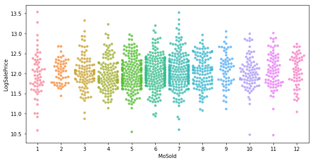

```python
fig = plt.figure(figsize=(10, 5))
sns.swarmplot(data=initial_train, x='MoSold', y='LogSalePrice', alpha=0.8)
plt.show()
```

It's a bit dubious but there might be some cyclic behaviour (with troughs at month 4 and 8?). This might not be a particularly powerful feature, but I will go ahead and apply a transformation.

```python
# Convert to a cyclic feature
initial_train['MoSold_cos'] = np.cos(2 * np.pi * initial_train['MoSold'] / 12)
initial_train['MoSold_sin'] = np.sin(2 * np.pi * initial_train['MoSold'] / 12)
initial_train.drop(columns=['MoSold'], inplace=True)

initial_test['MoSold_cos'] = np.cos(2 * np.pi * initial_test['MoSold'] / 12)
initial_test['MoSold_sin'] = np.sin(2 * np.pi * initial_test['MoSold'] / 12)
initial_test.drop(columns=['MoSold'], inplace=True)

remaining_num_cols = remaining_num_cols + ['MoSold_cos', 'MoSold_sin']
remaining_num_cols.remove('MoSold')
```

#### Linearity with the response

For the numeric columns, first I want to check the relationship with each to the response. This can give us a bivariate view of our data. We will quantify the relationship a bit later, but first I will plot each numeric variable against the response. At the same time I will plot a simple regression line for each plot and determine the r-square value as a quick measure of fit. I will keep this simple (including finding the r-squared using the training data) as this is merely done to aid visualisation, rather than perform any kind of concrete prediction or feature selection.

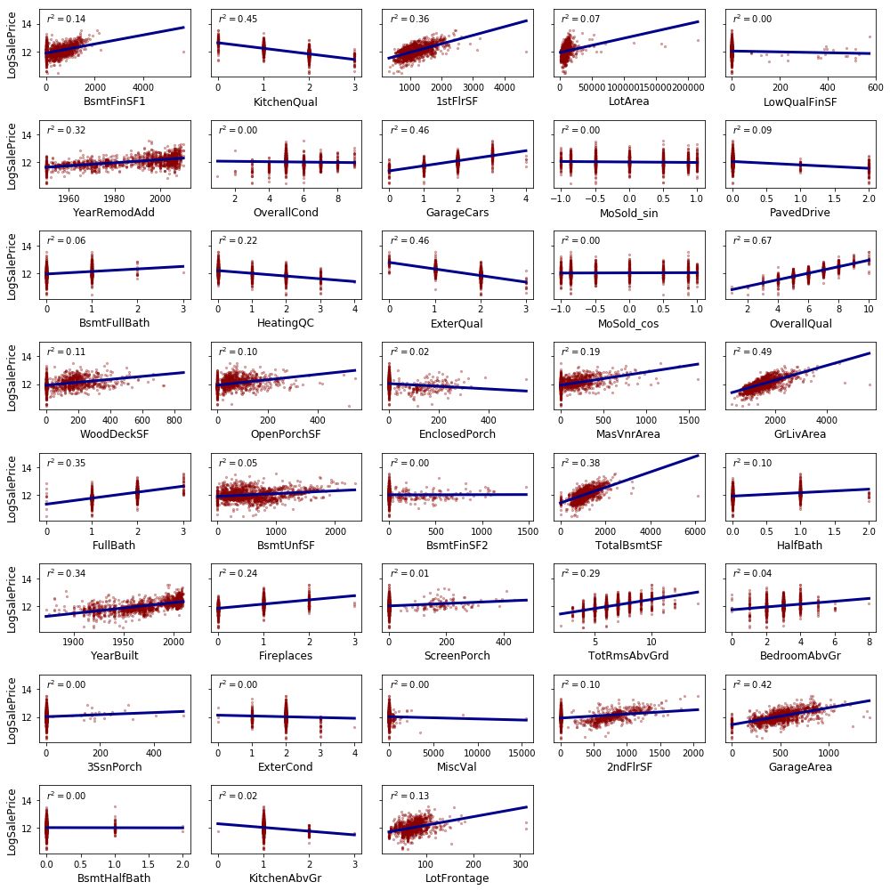

```python
from sklearn.linear_model import LinearRegression
from sklearn.metrics import r2_score

n_cols = 5
n_rows = int(np.ceil(len(remaining_num_cols) / n_cols))
fig, ax = plt.subplots(n_rows, n_cols, figsize=(14, 14), sharey=True)

id_row = 0
id_col = 0
ax[id_row, id_col].set_ylabel('LogSalePrice', fontsize=12)
for i, sp in enumerate({var for var in sorted(remaining_num_cols) if var != 'LogSalePrice'}):

    # Fit a linear regression for this feature only to be able to show a line
    x_train = initial_train[sp].values
    # Only use non-missing, finite values
    use_logic = np.isfinite(x_train.astype(float))
    x_train = x_train[use_logic]
    y_train = initial_train['LogSalePrice'].values[use_logic]
    x_min, x_max = x_train.min(), x_train.max()
    lr = LinearRegression()
    lr.fit(x_train.reshape(-1, 1), y_train)
    preds_train = lr.predict(x_train.reshape(-1, 1))
    r2_val = r2_score(y_train, preds_train)
    y_lbf_low, y_lbf_high = lr.predict(np.array([x_min, x_max]).reshape(-1, 1))

    ax[id_row, id_col].scatter(initial_train[sp], initial_train['LogSalePrice'], color='darkred', alpha=0.3, s=5)
    ax[id_row, id_col].set_xlabel(sp, fontsize=12)
    ax[id_row, id_col].plot([x_min, x_max], [y_lbf_low, y_lbf_high], color='darkblue', linewidth=3)
    ax[id_row, id_col].text(0.05, 0.8, '$r^{} = {:.2f}$'.format(2, r2_val), transform=ax[id_row, id_col].transAxes)

    # update row and column count
    if id_col == n_cols - 1:
        id_row += 1
        id_col = 0
        if i < (n_cols * n_rows - 1):
            ax[id_row, id_col].set_ylabel('LogSalePrice', fontsize=12)
    else:
        id_col += 1

# Remove axes of extraneous subplots
for k in np.arange(i - 1, n_rows * n_cols - 2):

    fig.delaxes(ax[id_row, id_col])

    # update row and column count
    if id_col == n_cols - 1:
        id_row += 1
        id_col = 0
    else:
        id_col += 1

plt.tight_layout()
plt.show()
```

Here we can see we have some reasonably strong relationships between several predictors and the log sales price. Most notably, the `OverallQual`, `ExterQual`, `GrLivArea`, `GarageCars` seem to be somewhat well correlated with the response.

This plot also suggests we may be able to use the ordinal variables as numeric variables without having to edit them. Interestingly, at least from these plots it doesn't appear outliers are having too high an effect on the relationships. Take `GrLivArea`, where there are a couple of high ground area properties with unusually low prices. As a result, I won't do any explicit outlier removal at this time.

One of the key assumptions for many regression tasks (such as what we will try later), is the assumption of linearity of each independent variable and the response. We may be able to improve this for some of our data by applying a log transformation, so long as all of a variable's values are greater than zero. Having normally distributed features can also help machine learning algorithms.

```python
min_vals = initial_train[remaining_num_cols].min()
print(min_vals[min_vals > 0])
```

```
LotFrontage       21.000000
LotArea         1300.000000
OverallQual        1.000000
OverallCond        1.000000
1stFlrSF         334.000000
GrLivArea        334.000000
TotRmsAbvGrd       2.000000
LogSalePrice      10.460242
YearBuilt       1872.000000
YearRemodAdd    1950.000000
dtype: float64
```

We can immediately transform these. Note that I will not do year variables, nor any other ordinal variables.

```python
initial_train['LogLotFrontage'] = np.log(initial_train['LotFrontage'])
initial_train['LogGrLivArea'] = np.log(initial_train['GrLivArea'])
initial_train['LogLotArea'] = np.log(initial_train['LotArea'])
initial_train['Log1stFlrSF'] = np.log(initial_train['1stFlrSF'])

new_numeric_cols = [var if var not in ['LotFrontage', 'GrLivArea', 'LotArea', '1stFlrSF'] else 'Log' + var
                       for var in remaining_num_cols]
```

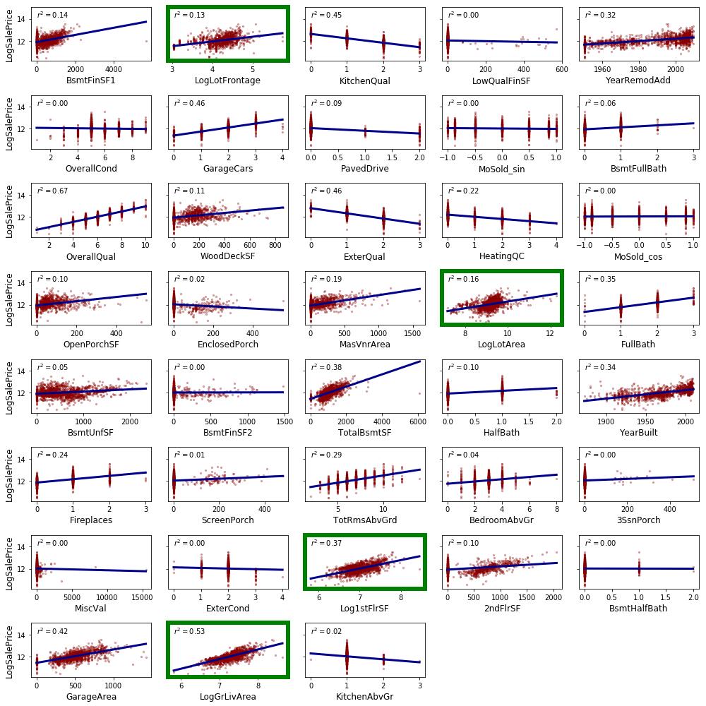

```python
n_cols = 5
n_rows = int(np.ceil(len(new_numeric_cols) / n_cols))
fig, ax = plt.subplots(n_rows, n_cols, figsize=(14, 14), sharey=True)

id_row = 0
id_col = 0
ax[id_row, id_col].set_ylabel('LogSalePrice', fontsize=12)
for i, sp in enumerate({var for var in new_numeric_cols if var != 'LogSalePrice'}):

    x_train = initial_train[sp].values
    use_logic = np.isfinite(x_train.astype(float))
    x_train = x_train[use_logic]
    y_train = initial_train['LogSalePrice'].values[use_logic]
    x_min, x_max = x_train.min(), x_train.max()
    lr = LinearRegression()
    lr.fit(x_train.reshape(-1, 1), y_train)
    preds_train = lr.predict(x_train.reshape(-1, 1))
    r2_val = r2_score(y_train, preds_train)
    y_lbf_low, y_lbf_high = lr.predict(np.array([x_min, x_max]).reshape(-1, 1))

    ax[id_row, id_col].scatter(initial_train[sp], initial_train['LogSalePrice'], color='darkred', alpha=0.3, s=5)
    ax[id_row, id_col].set_xlabel(sp, fontsize=12)
    ax[id_row, id_col].plot([x_min, x_max], [y_lbf_low, y_lbf_high], color='darkblue', linewidth=3)
    ax[id_row, id_col].text(0.05, 0.8, '$r^{} = {:.2f}$'.format(2, r2_val), transform=ax[id_row, id_col].transAxes)

    if sp.startswith('Log'):
        for spine in ax[id_row, id_col].spines.values():
            spine.set_edgecolor('green')
            spine.set_linewidth(6)

    # update row and column count
    if id_col == n_cols - 1:
        id_row += 1
        id_col = 0
        if i < (n_cols * n_rows - 1):
            ax[id_row, id_col].set_ylabel('LogSalePrice', fontsize=12)
    else:
        id_col += 1


for k in np.arange(i - 1, n_rows * n_cols - 2):

    fig.delaxes(ax[id_row, id_col])

    # update row and column count
    if id_col == n_cols - 1:
        id_row += 1
        id_col = 0
    else:
        id_col += 1



plt.tight_layout()
plt.show()
```

As we can see from these transformations (edited variables are have had their plots highlighted in green), the fits generally appear to be better than the above. Similarly, outliers for these seem less prominent. As a result, I won't remove any outliers at this stage, but it is worth bearing in mind improvements could be garnered by looking in more detail at possible outlier values.

```python
initial_test['LogLotFrontage'] = np.log(initial_test['LotFrontage'])
initial_test['LogGrLivArea'] = np.log(initial_test['GrLivArea'])
initial_test['LogLotArea'] = np.log(initial_test['LotArea'])
initial_test['Log1stFlrSF'] = np.log(initial_test['1stFlrSF'])
```

#### Quantifying and investigating relationships

As I've already log transformed the response, I will look at correlations using Spearman rank correlation, which is invariant under monotonic transforms.

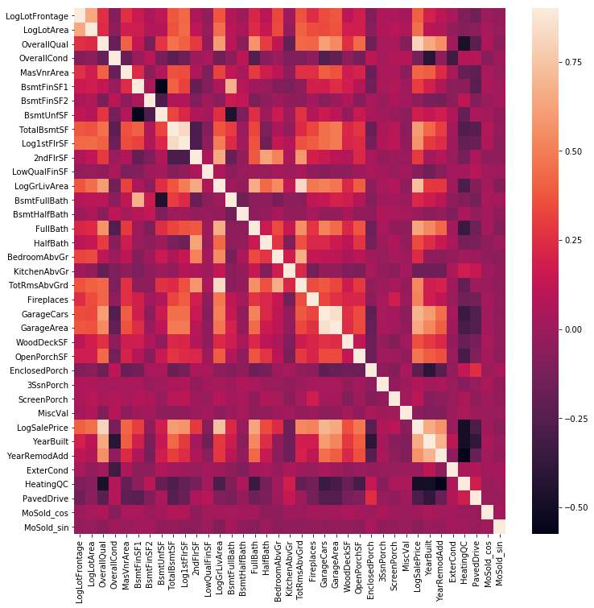

|  | LogLotFrontage | LogLotArea | OverallQual | OverallCond | MasVnrArea | BsmtFinSF1 | BsmtFinSF2 | BsmtUnfSF | TotalBsmtSF | Log1stFlrSF | 2ndFlrSF | LowQualFinSF | LogGrLivArea | BsmtFullBath | BsmtHalfBath | FullBath | HalfBath | BedroomAbvGr | KitchenAbvGr | TotRmsAbvGrd | Fireplaces | GarageCars | GarageArea | WoodDeckSF | OpenPorchSF | EnclosedPorch | 3SsnPorch | ScreenPorch | MiscVal | … |
| --- | --- | --- | --- | --- | --- | --- | --- | --- | --- | --- | --- | --- | --- | --- | --- | --- | --- | --- | --- | --- | --- | --- | --- | --- | --- | --- | --- | --- | --- | --- |
| LogLotFrontage | 1.000000 | 0.649683 | 0.255228 | -0.083110 | 0.259096 | 0.154431 | 0.052599 | 0.119588 | 0.387076 | 0.428300 | 0.054780 | -0.030200 | 0.375866 | 0.086218 | -0.003778 | 0.220024 | 0.096441 | 0.327663 | 0.002342 | 0.365930 | 0.245609 | 0.351635 | 0.378269 | 0.109146 | 0.178416 | -0.095682 | 0.064020 | 0.043912 | 0.024263 | … |
| LogLotArea | 0.649683 | 1.000000 | 0.233464 | -0.046848 | 0.177619 | 0.172234 | 0.072047 | 0.077882 | 0.366709 | 0.444279 | 0.119230 | -0.020251 | 0.449057 | 0.095720 | 0.046018 | 0.235317 | 0.142591 | 0.337787 | -0.022737 | 0.405931 | 0.350408 | 0.340146 | 0.367294 | 0.184287 | 0.177126 | -0.066512 | 0.062308 | 0.092346 | 0.059298 | … |
| OverallQual | 0.255228 | 0.233464 | 1.000000 | -0.178103 | 0.413211 | 0.132341 | -0.117874 | 0.272905 | 0.459438 | 0.408321 | 0.290051 | -0.034127 | 0.603335 | 0.097561 | -0.050817 | 0.577265 | 0.299518 | 0.121662 | -0.192615 | 0.428368 | 0.420196 | 0.609235 | 0.541431 | 0.259718 | 0.434669 | -0.162761 | 0.032811 | 0.046130 | -0.088185 | … |
| OverallCond | -0.083110 | -0.046848 | -0.178103 | 1.000000 | -0.179595 | -0.011655 | 0.102332 | -0.128458 | -0.218342 | -0.167446 | 0.001441 | 0.039509 | -0.153786 | -0.053051 | 0.115941 | -0.262162 | -0.070870 | -0.003608 | -0.099842 | -0.104704 | -0.045834 | -0.254665 | -0.201007 | -0.042477 | -0.133742 | 0.109615 | 0.032341 | 0.074618 | 0.086560 | … |
| MasVnrArea | 0.259096 | 0.177619 | 0.413211 | -0.179595 | 1.000000 | 0.241106 | -0.061559 | 0.075441 | 0.359628 | 0.351958 | 0.063552 | -0.107086 | 0.322711 | 0.120596 | 0.032742 | 0.290967 | 0.169629 | 0.113300 | -0.049509 | 0.264342 | 0.255221 | 0.401900 | 0.364557 | 0.173905 | 0.208241 | -0.179843 | 0.040930 | 0.038028 | -0.050396 | … |

```python
fig = plt.figure(figsize=(12,12))
correlation_matrix = initial_train[new_numeric_cols].corr(method='spearman')
sns.heatmap(correlation_matrix, vmax=0.9)
plt.show()
correlation_matrix.head()
```

This shows us all numeric variables' correlations with each other, however it can be a little bit difficult to interpret. Next I am showing each feature's correlation with the target variable.

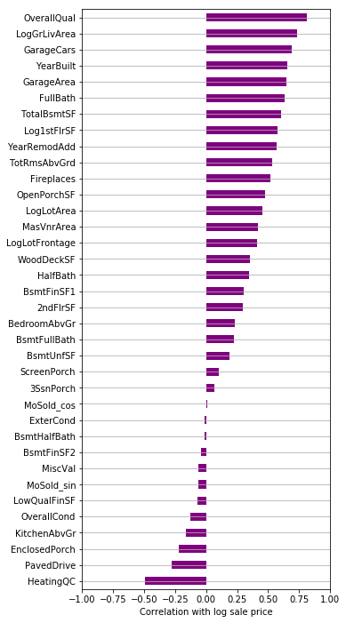

```python
corr_with_target = correlation_matrix['LogSalePrice'].drop('LogSalePrice')

fig = plt.figure(figsize=(5,12))
corr_with_target.sort_values(ascending=True).plot(kind='barh', color='purple')
plt.xlim(-1, 1)
plt.xlabel('Correlation with log sale price')
plt.grid(axis='y')
plt.show()
```

There are several features that are strongly correlated with the response, `OverallQual` in particular! Now is a good time to select some correlated feature variables to remove because the correlations between some of them may introduce multicollinearity which can impede the model results. For now, look at features with high correlation between themselves:

```python
correlation_matrix_small = correlation_matrix.copy().drop(['LogSalePrice']).drop(columns=['LogSalePrice']).unstack()
correlation_matrix_small = correlation_matrix_small[(correlation_matrix_small.abs() > 0.7) & (correlation_matrix_small != 1)]
correlation_matrix_small.sort_values(ascending=False)
```

```
GarageArea    GarageCars      0.853486
GarageCars    GarageArea      0.853486
Log1stFlrSF   TotalBsmtSF     0.829112
TotalBsmtSF   Log1stFlrSF     0.829112
TotRmsAbvGrd  LogGrLivArea    0.828023
LogGrLivArea  TotRmsAbvGrd    0.828023
dtype: float64
```

It appears from this that we might want to remove a couple of redundant variables. For example, 'GarageArea' is strongly correlated with 'GarageCars' so we will remove this variable (as it is itself slightly less correlated than 'GarageCars' with the sales price). Similarly, we will drop '1stFlrSF' and 'TotRmsAbvGrd'.

```python
drop_numeric_cols = ['GarageArea', 'Log1stFlrSF', 'TotRmsAbvGrd']
initial_train.drop(columns=drop_numeric_cols, inplace=True)
initial_test.drop(columns=drop_numeric_cols, inplace=True)

new_numeric_cols = [col for col in new_numeric_cols if col not in drop_numeric_cols]
```

Quite a few features have strong correlation with the house price. Before investigating some of the top ones further, we can check which are ordinal and which are continuous by assuming those with few unique values relative to the total observations are discrete.

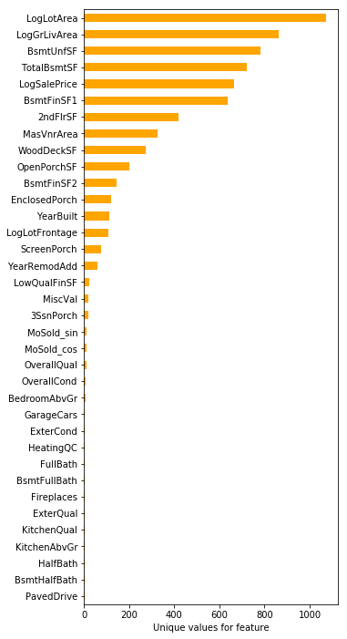

```python
cols_numeric_uniques = initial_train[new_numeric_cols].nunique().sort_values()
fig = plt.figure(figsize=(5,12))
cols_numeric_uniques.plot(kind='barh', color='orange')
plt.xlabel('Unique values for feature')
plt.show()
```

With the caveat that some continuous variables might appear to have low numbers due to potentially mostly being zero, we can see there are several variables which might actually be ordinal. Looking into 'OverallQual', the variable most correlated with the sales price:

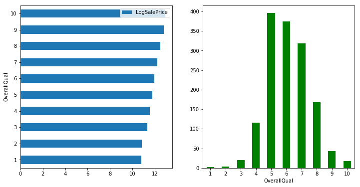

```python
overqual_means = initial_train[['LogSalePrice','OverallQual']].groupby('OverallQual').mean()
overqual_counts = initial_train.groupby('OverallQual').size()
fig, (ax1, ax2) = plt.subplots(1, 2, figsize=(12, 6))
overqual_means.plot(kind='barh', ax=ax1)
overqual_counts.plot(kind='bar', ax=ax2, rot=0, color='g')
plt.show()
```

Note that we are using the natural logarithm of the 'SalePrice' so differences may look slightly less clear than if we weren't, but it can clearly be seen that a higher overall quality is worth more!

```python
continuous_vars = cols_numeric_uniques[(cols_numeric_uniques >= 50)].index
discrete_vars = cols_numeric_uniques[~(cols_numeric_uniques >= 50)].index
print(continuous_vars)
```

```
Index(['YearRemodAdd', 'ScreenPorch', 'LogLotFrontage', 'YearBuilt',
       'EnclosedPorch', 'BsmtFinSF2', 'OpenPorchSF', 'WoodDeckSF',
       'MasVnrArea', '2ndFlrSF', 'BsmtFinSF1', 'LogSalePrice', 'TotalBsmtSF',
       'BsmtUnfSF', 'LogGrLivArea', 'LogLotArea'],
      dtype='object')
```

In conclusion for the numeric variables, I will do the following:

- consider ordinal variables as okay to be used in the same way as I am using the continuous variables
- the log-transformed independent variables will be used where they exist instead of their originals
- the remaining numeric variables which haven't yet been dropped will be put into the models as they are not overly-correlated with other (numeric) variables. It may be worth seeing if any others are correlated with the categorical ones.

```python
initial_train.drop(columns=['LotFrontage', 'GrLivArea', 'LotArea', '1stFlrSF'], inplace=True)
initial_test.drop(columns=['LotFrontage', 'GrLivArea', 'LotArea', '1stFlrSF'], inplace=True)
```

#### Dealing with missing values

```python
still_missing_train = initial_train.isna().mean().sort_values(ascending=False)
print(still_missing_train[still_missing_train > 0])
```

```
LogLotFrontage    0.177519
MasVnrArea        0.005483
dtype: float64
```

We still have missing values for two variables. The Lot frontage is missing for about 18% in the training dataset, so we need to impute this somehow (there is still enough non-missings to make it worth not dropping the feature entirely). On the other hand, the `MasVnrArea` has very few missing values, so I will impute this using the mean of the training set.

```python
mean_masvnrarea = initial_train.loc[~initial_train['MasVnrArea'].isna(), 'MasVnrArea'].mean()
print('Mean value of MasVnrArea: {:.1f}'.format(mean_masvnrarea))
initial_train['MasVnrArea'].fillna(mean_masvnrarea, inplace=True)
```

```
Mean value of MasVnrArea: 103.8
```

For the frontage there is not a huge amount of correlation with the response so I will not put too much effort into finding optimal missing values. However, I will perform a very simple linear regression to impute the missing values based upon the most correlated column with the lot frontage.

```python
corr_with_lotfrontage = correlation_matrix['LogLotFrontage'].abs().sort_values(ascending=False)[1:]
corr_with_lotfrontage.head(3)
```

```
LogLotArea      0.649683
Log1stFlrSF     0.428300
LogSalePrice    0.409058
Name: LogLotFrontage, dtype: float64
```

Surprise, surprise. The lot area is most correlated with the lot frontage. Visualising the relationship:

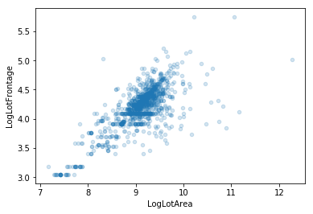

```python
plt.figure(figsize=(8, 5))
initial_train.plot.scatter(x='LogLotArea', y='LogLotFrontage', alpha=0.2)
plt.show()
```

We can fit a quick linear regression to this to get an estimate of a missing value for `LogLotFrontage` from that of `LotArea`. I will not spend too long doing this, nor will I do any complex model assessment. However, I will deal with outliers in the above plot by only using training data with up to 11 log lot area and 5.5 log lot frontage.

```python
from sklearn.linear_model import LinearRegression
from sklearn.metrics import r2_score

use_in_lot_model = initial_train[['LogLotArea', 'LogLotFrontage']].dropna()
use_in_lot_model_x = use_in_lot_model.loc[(use_in_lot_model['LogLotArea'] <= 11) &
                                          (use_in_lot_model['LogLotFrontage'] <= 5.5), 'LogLotArea'].values
use_in_lot_model_y = use_in_lot_model.loc[(use_in_lot_model['LogLotArea'] <= 11) &
                                          (use_in_lot_model['LogLotFrontage'] <= 5.5), 'LogLotFrontage'].values
linreg_lot = LinearRegression()
linreg_lot.fit(use_in_lot_model_x.reshape(-1, 1), use_in_lot_model_y)
lot_model_train_res = linreg_lot.predict(use_in_lot_model_x.reshape(-1, 1))

print("R-squared on the training data: {:.2f}".format(r2_score(use_in_lot_model_y,lot_model_train_res)))

initial_train['ImputedLogLotFrontage'] = linreg_lot.predict(initial_train['LogLotArea'].values.reshape(-1, 1))
lot_model_line = lambda x: linreg_lot.intercept_ + x * linreg_lot.coef_[0]
```

```
R-squared on the training data: 0.56
```

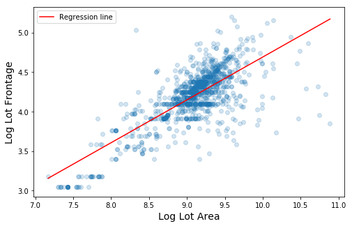

```python
plt.figure(figsize=(8, 5))
# initial_train.plot.scatter(x='LotArea', y='LogLotFrontage', alpha=0.2)
plt.scatter(use_in_lot_model_x, use_in_lot_model_y, alpha=0.2)
xvals = np.array([use_in_lot_model_x.min(), use_in_lot_model_x.max()])
yvals = lot_model_line(xvals)
plt.plot(xvals, yvals, color='red', label='Regression line')
plt.xlabel('Log Lot Area', fontsize=14)
plt.ylabel('Log Lot Frontage', fontsize=14)
plt.legend()
plt.show()
```

```python
initial_train['LogLotFrontage'].fillna(initial_train['ImputedLogLotFrontage'], inplace=True)
```

## Checking the test data

```python
still_missing_test = initial_test.isna().mean().sort_values(ascending=False)
print(still_missing_test[still_missing_test > 0])
```

```
LogLotFrontage    0.155586
MasVnrArea        0.010281
BsmtFullBath      0.001371
BsmtHalfBath      0.001371
GarageCars        0.000685
BsmtUnfSF         0.000685
BsmtFinSF1        0.000685
TotalBsmtSF       0.000685
BsmtFinSF2        0.000685
dtype: float64
```

There are a few missing data points for several columns. The `MasVnrArea` and `LotFrontage` can be fixed by using the same procedure as above.

```python
initial_test['MasVnrArea'].fillna(mean_masvnrarea, inplace=True)
initial_test['ImputedLogLotFrontage'] = linreg_lot.predict(initial_test['LogLotArea'].values.reshape(-1, 1))
initial_test['LogLotFrontage'].fillna(initial_test['ImputedLogLotFrontage'], inplace=True)
```

However, we have a few new variables missing values we need to fix.

```python
still_missing_test = initial_test.isna().sum().sort_values(ascending=False)
print(still_missing_test[still_missing_test > 0])
```

```
BsmtFullBath    2
BsmtHalfBath    2
BsmtUnfSF       1
GarageCars      1
TotalBsmtSF     1
BsmtFinSF1      1
BsmtFinSF2      1
dtype: int64
```

Again, as there are so few missing values, I will replace them with their respective mean (from the training set).

```python
initial_test['BsmtHalfBath'].fillna(initial_train['BsmtHalfBath'].mean(), inplace=True)
initial_test['BsmtFullBath'].fillna(initial_train['BsmtFullBath'].mean(), inplace=True)
initial_test['BsmtFinSF2'].fillna(initial_train['BsmtFinSF2'].mean(), inplace=True)
initial_test['BsmtUnfSF'].fillna(initial_train['BsmtUnfSF'].mean(), inplace=True)
initial_test['TotalBsmtSF'].fillna(initial_train['TotalBsmtSF'].mean(), inplace=True)
initial_test['BsmtFinSF1'].fillna(initial_train['BsmtFinSF1'].mean(), inplace=True)
initial_test['GarageCars'].fillna(initial_train['GarageCars'].mean(), inplace=True)
```

```python
cleaned_numeric_cols = [col for col in new_numeric_cols if col != 'LogSalePrice']
cleaned_cat_cols = remaining_cat_cols
cleaned_cat_cols_ohe = list(retain_ohe_columns)
```

A reminder of our columns:

```python
(cleaned_numeric_cols + cleaned_cat_cols)
```

```
['LogLotFrontage',
 'LogLotArea',
 'OverallQual',
 'OverallCond',
 'MasVnrArea',
 'BsmtFinSF1',
 'BsmtFinSF2',
 'BsmtUnfSF',
 'TotalBsmtSF',
 '2ndFlrSF',
 'LowQualFinSF',
 'LogGrLivArea',
 'BsmtFullBath',
 'BsmtHalfBath',
 'FullBath',
 'HalfBath',
 'BedroomAbvGr',
 'KitchenAbvGr',
 'Fireplaces',
 'GarageCars',
 'WoodDeckSF',
 'OpenPorchSF',
 'EnclosedPorch',
 '3SsnPorch',
 'ScreenPorch',
 'MiscVal',
 'YearBuilt',
 'YearRemodAdd',
 'ExterQual',
 'ExterCond',
 'HeatingQC',
 'KitchenQual',
 'PavedDrive',
 'MoSold_cos',
 'MoSold_sin',
 'MSZoning',
 'Street',
 'Alley',
 'LotShape',
 'LandContour',
```

[output cut: 16 more lines]

```
 'BsmtFinType1',
 'BsmtFinType2',
 'Heating',
 'CentralAir',
 'Electrical',
 'Functional',
 'FireplaceQu',
 'GarageType',
 'GarageFinish',
 'GarageQual',
 'GarageCond',
 'SaleType',
 'SaleCondition',
 'MSSubClass',
 'YrSold']
```

```python
feature_cols = cleaned_numeric_cols + cleaned_cat_cols_ohe
response_col = 'LogSalePrice'

full_model_set_train = pd.concat((initial_train[[response_col] + cleaned_numeric_cols], train_ohe,
                                  initial_train['Neighborhood']), sort=False, axis=1)
full_model_set_test = pd.concat((initial_test[cleaned_numeric_cols], test_ohe,
                                  initial_test['Neighborhood']), sort=False, axis=1)
```

# Modelling

Now data pre-processing has been performed, models can now be fit to learn from the data. As a reminder, I am trying to predict the log of the sales price from the features explored above.

The evaluation metric is the root mean square error between the log of the predicted price and the log of the true price.

## Simple linear regression

It's good to start with a simple, baseline model to which comparisons can be made. To this end, I will create a simple linear regression model using all of the features. I will use a simple split into training and test set. Note that until the final test set is used, I refer to holdout sets as test.

```python
from sklearn.metrics import mean_squared_error
from sklearn.preprocessing import StandardScaler, RobustScaler
from sklearn.model_selection import train_test_split

# from sklearn.metrics import make_scorer
# scorer = make_scorer(mean_squared_error, greater_is_better=False)

# Split the data into a training and holdout set. Retain the indexes of the DataFrame
X_train, X_test, y_train, y_test, indexes_train, indexes_test = train_test_split(full_model_set_train[feature_cols],
                                                    full_model_set_train[response_col],
                                                    full_model_set_train.index,
                                                    random_state=2,
                                                    test_size=0.3)

# Standardise the data (most of the following models also follow this approach)
ss_initial = StandardScaler()
X_train_orig = X_train.copy()
X_test_orig = X_test.copy()
X_train = ss_initial.fit_transform(X_train)
X_test = ss_initial.transform(X_test)

# Use scikit-learn to fit a regression to the data
skl_reg = LinearRegression()
skl_reg.fit(X_train, y_train)
skl_reg_preds_train = skl_reg.predict(X_train)
skl_reg_preds_test = skl_reg.predict(X_test)


print("TRAIN) Quick model RMSE of logged response: {:.4f}".format(mean_squared_error(y_train, skl_reg_preds_train)))
print("TEST) Quick model RMSE of logged response: {:.4f}".format(mean_squared_error(y_test, skl_reg_preds_test)))
```

```
TRAIN) Quick model RMSE of logged response: 0.0111
TEST) Quick model RMSE of logged response: 9626049951734102016.0000
```

I've spent a lot of time (far too much!) trying to understand why the test RMSE is so wild. My investigation suggests that the 'BsmtFinType2_None' column is the culprit, and only a single value in the test set has an unusually different predicted value. However, the value for this column for the strange observation is typical (it is a one in an encoded column - but not the only observation with a value of one).

Manually reconstructing the estimates using the coefficients and intercepts still returns the same strange result, suggesting that it is a problem with one or more coefficients rather than the underlying data.

#### Abridged investigation

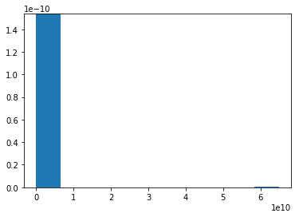

```python
# Distribution of predictions for the test set
_ = plt.hist(skl_reg_preds_test, density=True)
```

The distribution of predicted holdout set values suggest that very few are strangely different and skewing the results.

```python
print('Typical prediction: {}'.format(np.median(skl_reg_preds_test)))
```

```
Typical prediction: 12.024371353034812
```

```python
strange_predictions = np.abs(skl_reg_preds_test) >= 14
print('Unusual predictions: {}'.format(skl_reg_preds_test[strange_predictions]))
```

```
Unusual predictions: [6.49323485e+10]
```

Only one prediction is very big!

```python
# BsmtFinType2_NoneExist is the column which causes the problem (tested by removing columns and rerunning the model -
# if this is excluded the model is fine)
strange_value = X_test_orig.loc[strange_predictions, 'BsmtFinType2_NoneExist'].values[0]
same_values = X_test_orig['BsmtFinType2_NoneExist'] == strange_value
print("There are {} other observations with the same value for the troublesome column (BsmtFinType2_NoneExist) as the "
      "observation with a strange predicted value."
      .format(same_values.sum() - 1))
```

```
There are 9 other observations with the same value for the troublesome column (BsmtFinType2_NoneExist) as the observation with a strange predicted value.
```

I'm going to try again but use statsmodels instead of scikit-learn.

## Simple linear regression with statsmodels

```python
import statsmodels.formula.api as smf
import statsmodels.api as sm
endog = y_train
exog = X_train
exog = sm.add_constant(exog, prepend=False)
sm_reg = smf.OLS(endog=endog, exog=exog).fit()

inpred_train = sm.add_constant(X_train, prepend=False)
inpred_test = sm.add_constant(X_test, prepend=False)
sm_reg_preds_train = sm_reg.predict(inpred_train)
sm_reg_preds_test = sm_reg.predict(inpred_test)
print("TRAIN) Quick model RMSE of logged response: {:.4f}".format(mean_squared_error(y_train, sm_reg_preds_train)))
print("TEST) Quick model RMSE of logged response: {:.4f}".format(mean_squared_error(y_test, sm_reg_preds_test)))
```

```
TRAIN) Quick model RMSE of logged response: 0.0111
TEST) Quick model RMSE of logged response: 0.0174
```

This is much better; we now have a baseline model to compare to.

```python
print(sm_reg.summary(xname=list(X_train_orig.columns) + ['intercept']))
```

```
                            OLS Regression Results
==============================================================================
Dep. Variable:           LogSalePrice   R-squared:                       0.931
Model:                            OLS   Adj. R-squared:                  0.917
Method:                 Least Squares   F-statistic:                     67.61
Date:                Sun, 30 Jun 2019   Prob (F-statistic):               0.00
Time:                        13:09:46   Log-Likelihood:                 850.73
No. Observations:                1021   AIC:                            -1361.
Df Residuals:                     851   BIC:                            -523.6
Df Model:                         169
Covariance Type:            nonrobust
==========================================================================================
                             coef    std err          t      P>|t|      [0.025      0.975]
------------------------------------------------------------------------------------------
LogLotFrontage            -0.0061      0.008     -0.747      0.455      -0.022       0.010
LogLotArea                 0.0401      0.009      4.510      0.000       0.023       0.058
OverallQual                0.0649      0.009      7.580      0.000       0.048       0.082
OverallCond                0.0415      0.006      7.044      0.000       0.030       0.053
MasVnrArea                -0.0015      0.006     -0.241      0.809      -0.014       0.011
BsmtFinSF1                -0.0043      0.005     -0.851      0.395      -0.014       0.006
BsmtFinSF2                 0.0115      0.008      1.502      0.133      -0.004       0.027
BsmtUnfSF              -6.132e-05      0.005     -0.012      0.991      -0.010       0.010
TotalBsmtSF               -0.0005      0.006     -0.083      0.934      -0.013       0.012
2ndFlrSF                   0.0287      0.014      2.062      0.040       0.001       0.056
LowQualFinSF              -0.0047      0.005     -1.003      0.316      -0.014       0.005
LogGrLivArea               0.1556      0.013     12.339      0.000       0.131       0.180
BsmtFullBath               0.0174      0.006      2.811      0.005       0.005       0.029
BsmtHalfBath              -0.0019      0.004     -0.454      0.650      -0.010       0.006
FullBath                   0.0171      0.007      2.308      0.021       0.003       0.032
HalfBath                   0.0077      0.006      1.206      0.228      -0.005       0.020
BedroomAbvGr              -0.0137      0.006     -2.234      0.026      -0.026      -0.002
KitchenAbvGr              -0.0020      0.008     -0.242      0.809      -0.019       0.014
Fireplaces                -0.0003      0.010     -0.034      0.973      -0.019       0.019
GarageCars                 0.0371      0.007      5.280      0.000       0.023       0.051
WoodDeckSF                 0.0133      0.004      3.012      0.003       0.005       0.022
OpenPorchSF               -0.0008      0.005     -0.183      0.855      -0.010       0.008
EnclosedPorch              0.0053      0.005      1.135      0.257      -0.004       0.014
3SsnPorch                  0.0036      0.004      0.924      0.356      -0.004       0.011
ScreenPorch                0.0148      0.004      3.639      0.000       0.007       0.023
MiscVal                   -0.0013      0.004     -0.317      0.751      -0.009       0.006
```

[output cut: 148 more lines]

```
YrSold_2008               -0.0053      0.005     -1.061      0.289      -0.015       0.005
YrSold_2009               -0.0096      0.005     -1.932      0.054      -0.019       0.000
YrSold_2010               -0.0050      0.005     -1.061      0.289      -0.014       0.004
intercept                 12.0155      0.004   3332.823      0.000      12.008      12.023
==============================================================================
Omnibus:                      405.046   Durbin-Watson:                   2.047
Prob(Omnibus):                  0.000   Jarque-Bera (JB):             5850.544
Skew:                          -1.414   Prob(JB):                         0.00
Kurtosis:                      14.381   Cond. No.                     1.62e+16
==============================================================================

Warnings:
[1] Standard Errors assume that the covariance matrix of the errors is correctly specified.
[2] The smallest eigenvalue is 6.12e-29. This might indicate that there are
strong multicollinearity problems or that the design matrix is singular.
```

Strangely, this works this time. I haven't done anything differently (except create a constant for the intercept which scikit-learn's implementation does natively). Definitely something to come back and look at in the future, but if I have a working version there's no point in getting hung up on this.

Below are the largest coefficients (remembering that we have already scaled the data) in absolute terms.

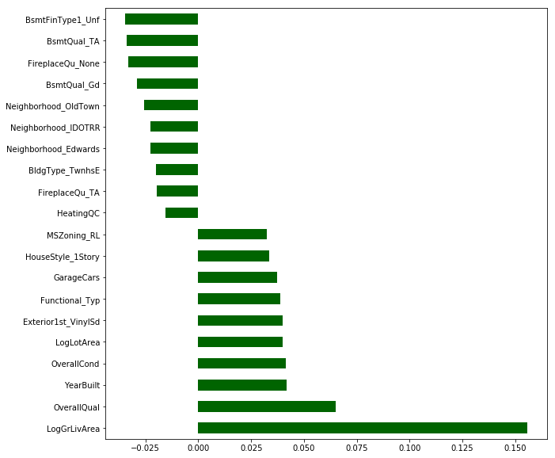

```python
fig = plt.figure(figsize=(10, 10))
coeffs_found = pd.Series(data=sm_reg.params.drop(sm_reg.params.tail(1).index).values,
                           index=X_train_orig.columns)

coeffs_found.sort_values(ascending=False, inplace=True)
main_coeffs = list(coeffs_found.head(10).index) + list(coeffs_found.tail(10).index)
coeffs_found.loc[main_coeffs].plot(kind='barh', color='darkgreen')
plt.show()
```

```python
def residual_plots(preds_train, preds_test):

    fig, (ax1, ax2, ax3) = plt.subplots(1, 3, figsize=(14, 5))

    # Calculate residuals
    resid_train = y_train - preds_train
    resid_test = y_test - preds_test

    # Preds vs true plot
    ax1.scatter(preds_train, y_train, alpha=0.1, color='green', label='Train')
    ax1.scatter(sm_reg_preds_test, y_test, alpha=0.1, color='red', label='Test')
    ax1.set_xlabel('Predicted', fontsize=14)
    ax1.set_ylabel('True', fontsize=14)
    ax1.legend(fontsize=13)
    x_min, x_max = ax1.get_xlim()
    y_min, y_max = ax1.get_ylim()
    ax1.plot([x_min, x_max], [y_min, y_max], color='black', alpha=0.5)


    # Residuals vs predicted plot
    ax2.scatter(preds_train, resid_train, alpha=0.1, color='green', label='Train')
    ax2.scatter(preds_test, resid_test, alpha=0.1, color='red', label='Test')
    ax2.set_xlabel('Residuals', fontsize=14)
    ax2.set_ylabel('Predicted', fontsize=14)
    ax2.legend(fontsize=13)
    x_min, x_max = ax2.get_xlim()
    ax2.plot([x_min, x_max], [0, 0], color='black', alpha=0.5)


    # Residuals hist plot
    resid_values = np.concatenate((resid_train, resid_test))
    hist_bins = np.linspace(np.min(resid_values), np.max(resid_values), 40)
    _ = ax3.hist(resid_train, bins=hist_bins, color='green', alpha=0.5, density=True, label='Train')
    _ = ax3.hist(resid_test, bins=hist_bins, color='red', alpha=0.5, density=True, label='Test')
    ax3.plot([0, 0], [0, ax3.get_ylim()[1]], color='black', alpha=0.5)
    x_min, x_max = ax3.get_xlim()
    x_vals = np.linspace(x_min, x_max, 101)
    mu_train, std_train = norm.fit(resid_train)
    norm_train = norm.pdf(x_vals, mu_train, std_train)
    ax3.plot(x_vals, norm_train, color='green', linewidth=2)
    mu_test, std_test = norm.fit(resid_test)
    norm_train = norm.pdf(x_vals, mu_test, std_test)
    ax3.plot(x_vals, norm_train, color='red', linewidth=2)
    ax3.set_xlabel('Residual', fontsize=14)
    ax3.set_ylabel('Density', fontsize=14)
    ax3.legend(fontsize=13)

    plt.tight_layout()
    plt.show()

    print('TRAIN) Mean of residuals: {:.3f}'.format(resid_train.mean()))
    print('TEST) Mean of residuals: {:.3f}'.format(resid_test.mean()))
```

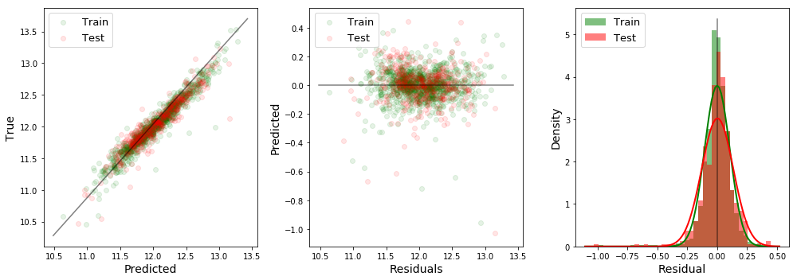

```
TRAIN) Mean of residuals: 0.000
TEST) Mean of residuals: 0.003
```

```python
residual_plots(sm_reg_preds_train, sm_reg_preds_test)
```

This does not look truly terrible, though it could be improved. The residuals appear normally distributed (though the histogram bins do not show this perfectly) with their mean being zero. There does not appear to be any heteroskedasticity in the residuals either.

There are a few models I wish to try out.

- regularised linear models
- tree-based methods
- random effects models

## Regularised regression and random forests

The first two of these I will perform in the same process. This will be to begin with a nested cross validation scheme to be able to highlight the most appropriate final model to use (with hyperparameter tuning taken into account). Once this is found, I will choose the best performing model to take forward and perform a grid search to determine the optimal hyperparameters.

The models to compare:

- Lasso: linear regression with regularisation applied from the l1-norm of the parameters, scaled by a parameter alpha. This is a good technique for shrinking 'redundant' variables' contributions to the model to zero.
- Ridge: linear regression with regularisation applied from the l2-norm of the parameters, scaled by a parameter alpha. This is somewhat similar to the above, with simpler models preferred.
- Elastic Net: a combination of the above two regularisation schemes, with a parameter (l1_ratio in scikit-learn) denoting the relative strengths of the l1 and l2 regularisations.
- Random Forest: similar to the classification algorithm, but with tree leaf nodes having their mean of their training labels taken to denote their predicted response.

```python
from sklearn.linear_model import Ridge, Lasso, ElasticNet
from sklearn.ensemble import RandomForestRegressor
from sklearn.model_selection import GridSearchCV, cross_val_score
from sklearn.pipeline import Pipeline

# Begin with Lasso regression
# We want to scale the data and run the model in a pipeline (so as not to bias
# the results from leaking test data into the scaling)
pipe_reg_l1 = Pipeline([('ss', StandardScaler()),
                       ('clf', Lasso(random_state=5))])
# Simply look for the best value for regularisation strength
params_reg_l1 = {'clf__alpha': np.logspace(-2, 4, 21)}
# This will perform the inner loop of the nested cross validation for this algorithm
gs_reg_l1 = GridSearchCV(estimator=pipe_reg_l1,
                        param_grid=params_reg_l1,
                        scoring='neg_mean_squared_error',
                        cv=2,
                        n_jobs=-1)
# The outer loop is performed here
scores_reg_l1 = -cross_val_score(gs_reg_l1,
                               full_model_set_train[feature_cols],
                               full_model_set_train[response_col],
                               scoring='neg_mean_squared_error',
                               cv=5)




# Ridge regression is pretty much identical to Lasso regression in terms of my set up
pipe_reg_l2 = Pipeline([('ss', StandardScaler()),
                       ('clf', Ridge(random_state=5))])
params_reg_l2 = {'clf__alpha': np.logspace(-2, 4, 21)}
gs_reg_l2 = GridSearchCV(estimator=pipe_reg_l2,
                        param_grid=params_reg_l2,
                        scoring='neg_mean_squared_error',
                        cv=2,
                        n_jobs=-1)
scores_reg_l2 = -cross_val_score(gs_reg_l2,
                               full_model_set_train[feature_cols],
                               full_model_set_train[response_col],
                               scoring='neg_mean_squared_error',
                               cv=5)

# Elastic Net requires a second hyperparameter - the relative strengths of the l1 and l2
# contributions to the regularisation
pipe_reg_l1l2 = Pipeline([('ss', StandardScaler()),
                       ('clf', ElasticNet(random_state=5))])
params_reg_l1l2 = {'clf__alpha': np.logspace(-2, 4, 21),
                  'clf__l1_ratio': np.linspace(0, 1.0, 11)}
gs_reg_l1l2 = GridSearchCV(estimator=pipe_reg_l1l2,
                        param_grid=params_reg_l1l2,
                        scoring='neg_mean_squared_error',
                        cv=2,
                        n_jobs=-1)
scores_reg_l1l2 = -cross_val_score(gs_reg_l1l2,
                               full_model_set_train[feature_cols],
                               full_model_set_train[response_col],
                               scoring='neg_mean_squared_error',
                               cv=5)


# Random forest regression - the same approach but with a different set of hyperparameters
pipe_reg_rf = Pipeline([('ss', StandardScaler()),
                       ('clf', RandomForestRegressor(random_state=5))])
params_reg_rf = {'clf__max_depth': np.linspace(1, 20, 20),
                  'clf__max_features': ["auto", "sqrt"],
                'clf__min_samples_split': np.linspace(0.1, 1, 10)}
gs_reg_rf = GridSearchCV(estimator=pipe_reg_rf,
                        param_grid=params_reg_rf,
                        scoring='neg_mean_squared_error',
                        cv=2,
                        n_jobs=-1)
scores_reg_rf = -cross_val_score(gs_reg_rf,
                               full_model_set_train[feature_cols],
                               full_model_set_train[response_col],
                               scoring='neg_mean_squared_error',
                               cv=5)

# Here we print the results from the mean score for each algorithm - this
# will be less biased than if we did not use nested cross validation
print('Nested CV RMSE for Lasso regression: {:.4f} +/- {:.4f}'
      .format(np.mean(scores_reg_l1), np.std(scores_reg_l1)))
print('Nested CV RMSE for Ridge regression: {:.4f} +/- {:.4f}'
      .format(np.mean(scores_reg_l2), np.std(scores_reg_l2)))
print('Nested CV RMSE for Elastic Net regression: {:.4f} +/- {:.4f}'
      .format(np.mean(scores_reg_l1l2), np.std(scores_reg_l1l2)))
print('Nested CV RMSE for random forest regression: {:.4f} +/- {:.4f}'
      .format(np.mean(scores_reg_rf), np.std(scores_reg_rf)))
```

[output not shown]

[output cut: 67 more lines]

[output not shown]

```
Nested CV RMSE for Lasso regression: 0.0184 +/- 0.0045
Nested CV RMSE for Ridge regression: 0.0180 +/- 0.0043
Nested CV RMSE for Elastic Net regression: 0.0170 +/- 0.0042
Nested CV RMSE for random forest regression: 0.0355 +/- 0.0036
```

```python
params_reg_l1l2 = {'alpha': np.logspace(-2, 4, 21),
                  'l1_ratio': np.linspace(0, 1.0, 11)}
gs_reg_l1l2 = GridSearchCV(estimator=ElasticNet(random_state=5),
                        param_grid=params_reg_l1l2,
                        scoring='neg_mean_squared_error',
                        cv=5,
                        n_jobs=-1)
_ = gs_reg_l1l2.fit(X_train, y_train)

best_model_preds_train = gs_reg_l1l2.predict(X_train)
best_model_preds_test = gs_reg_l1l2.predict(X_test)

print("TRAIN) Quick model RMSE of logged response: {:.4f}"
      .format(mean_squared_error(y_train, best_model_preds_train)))
print("TEST) Quick model RMSE of logged response: {:.4f}"
      .format(mean_squared_error(y_test, best_model_preds_test)))
```

```
TRAIN) Quick model RMSE of logged response: 0.0133
TEST) Quick model RMSE of logged response: 0.0167
```

While this at first glance the training set result appears worse than the first simple regression I performed, the test set result is much closer. This might suggest some overfitting for the original regression model (which makes sense as the regularisation in the Elastic Net directly reduces overfitting the training set). It is still not perfect.

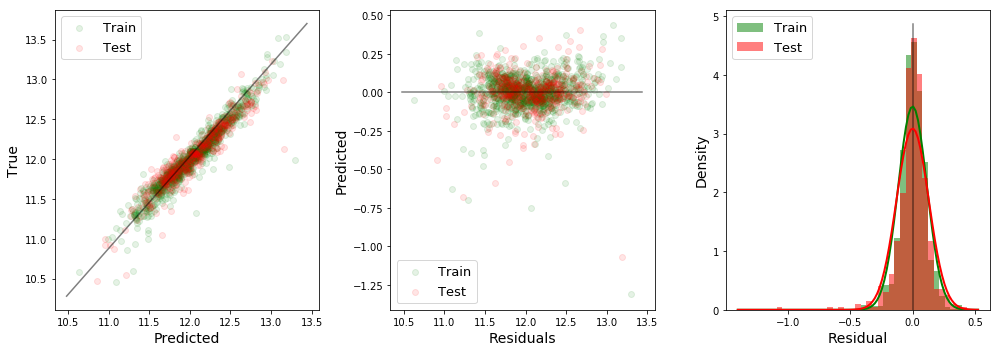

```
TRAIN) Mean of residuals: -0.000
TEST) Mean of residuals: 0.000
```

```python
residual_plots(best_model_preds_train, best_model_preds_test)
```

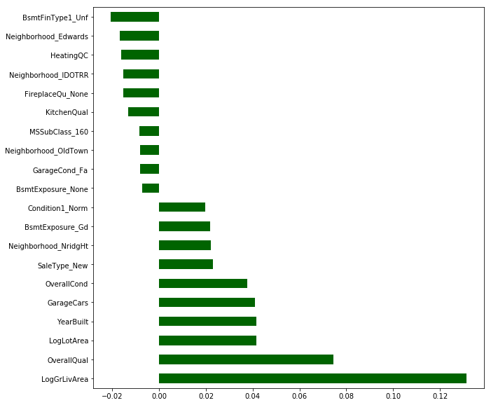

```python
best_model = gs_reg_l1l2.best_estimator_
fig = plt.figure(figsize=(10, 10))
coeffs_found = pd.Series(data=best_model.coef_,
                           index=X_train_orig.columns)

coeffs_found.sort_values(ascending=False, inplace=True)
main_coeffs = list(coeffs_found.head(10).index) + list(coeffs_found.tail(10).index)
coeffs_found.loc[main_coeffs].plot(kind='barh', color='darkgreen')
plt.show()
```

Predicting on the submission dataset.

```python
X_final = ss_initial.transform(full_model_set_test[feature_cols])

final_predictions = pd.DataFrame({'Id': initial_test['Id'],
                                  'SalePrice': np.exp(gs_reg_l1l2.predict(X_final))})
#final_predictions.to_csv(r'data\submissions\submission.csv', index=False)
```

## Mixed effects models

An alternate approach I am going to try is the use of mixed effects models. In this, we can treat a categorical predictor as a random, rather than fixed effect. In simple words, fixed effects will have an explicit coefficient estimate etcetera. On the other hand, random effects are values drawn from a normal distribution to represent the levels of clustered data. These values can, for example, be used as an intercept which varies across the groups (random intercept model) or as a varying coefficient for a fixed effect in a linear model. The benefit is that we can create a model which retains the effect of each level of the group without creating separate models for each, while pooling information from other levels. Similarly, if we have a lot of levels we might have issues encoding these as fixed effects. Mixed effects models necessarily help with this.

I will begin with a mixed effects random forest, whose documentation can be seen here: https://github.com/manifoldai/merf

```python
# Our random effect
# group_col = 'Neighborhood'
group_col = 'YearBuilt'

# Remove the random effect from the features - this creates a list of the fixed effects
all_other_feature_cols = [col for col in feature_cols if not
                          col.startswith(group_col[:4])] # and col in main_coeffs

# Split as before whilst retaining the indexes
Xr_train, Xr_test, yr_train, yr_test, ir_train, ir_test \
                                    = train_test_split(
                                        full_model_set_train[all_other_feature_cols],
                                        full_model_set_train[response_col],
                                        full_model_set_train.index,
                                        random_state=2,
                                        test_size=0.3)

# Scale data
ssr = StandardScaler()
Xr_train_std = ssr.fit_transform(Xr_train)

# This is our vector of random effects which is passed with values of one
Zr_train = np.ones((Xr_train_std.shape[0], 1))

# Random effect levels used with the Z vector above to create the random effect
clusters_train = full_model_set_train.loc[ir_train, group_col]
```

### Mixed effects random forests

```python
from merf import MERF

merf = MERF(min_iterations=2, max_iterations=5)
merf.fit(Xr_train_std, Zr_train, clusters_train, yr_train)
```

```
INFO     [merf.py:250] GLL is -2325.721782722262 at iteration 1.
INFO     [merf.py:250] GLL is -3388.567335502946 at iteration 2.
INFO     [merf.py:250] GLL is -3500.423634358369 at iteration 3.
INFO     [merf.py:250] GLL is -3525.094756874694 at iteration 4.
INFO     [merf.py:250] GLL is -3533.3506374838753 at iteration 5.
```

```
<merf.merf.MERF at 0x221a5d12668>
```

```python
Xr_test_std = ssr.transform(Xr_test)
Zr_test = np.ones((Xr_test_std.shape[0], 1))
clusters_test = full_model_set_train.loc[ir_test, group_col]

preds_train = merf.predict(Xr_train_std, Zr_train, clusters_train)
preds_test = merf.predict(Xr_test_std, Zr_test, clusters_test)

print("TRAIN) Quick model RMSE of logged response: {:.4f}"
      .format(mean_squared_error(y_train, preds_train)))
print("TEST) Quick model RMSE of logged response: {:.4f}"
      .format(mean_squared_error(y_test, preds_test)))
```

```
TRAIN) Quick model RMSE of logged response: 0.0026
TEST) Quick model RMSE of logged response: 0.0258
```

The RMSE is very good for the training set, a significant improvement on those earlier. However, this is likely a result of overfitting as the test RMSE is much worse. I have played around with different iterations and splits but this appears to remain the case.

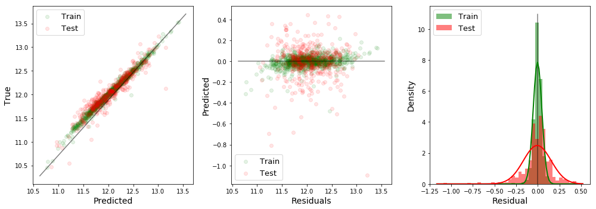

```
TRAIN) Mean of residuals: -0.003
TEST) Mean of residuals: -0.006
```

```python
residual_plots(preds_train, preds_test)
```

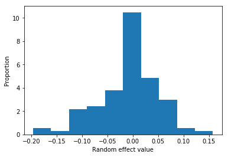

```python
plt.hist(merf.trained_b.values, density=True)
plt.xlabel('Random effect value')
plt.ylabel('Proportion')
plt.show()
```

This is approaching a normal distribution, though it does exhibit some skew. I'm not completely happy with this, so I will try a mixed effects linear model.

### Mixed effects linear model

This is similar to the above, except it is like a linear regression. I will be using a randomly sampled intercept to reflect the clustered variable. Note that I have had trouble with model convergence when using the full set of features (including issues with singular matrices with the one hot encoded variables). Therefore, I will use a subset of features (those with the biggest absolute coefficients found earlier).

```python
# n_comps = 5
# from sklearn.decomposition import PCA
# pca = PCA(n_components=n_comps)
# pca_train = pca.fit_transform(Xr_train_std)
# pca_test = pca.transform(Xr_test_std)
# np.sum(pca.explained_variance_ratio_)
```

```python
# exog_train = pca_train
# exog_test = pca_test

# Use subset of features - get index and name
use_cols = [all_other_feature_cols.index(i) for i in all_other_feature_cols if i in main_coeffs]
use_cols_names = [i for i in all_other_feature_cols if i in main_coeffs]

exog_train = Xr_train_std[:, use_cols]
exog_test = Xr_test_std[:, use_cols]
endog_train = yr_train
endog_test = yr_test

md = sm.MixedLM(endog_train, exog_train, groups=clusters_train,
               exog_re=Zr_train)
mdf = md.fit()
print(mdf.summary())
```

```
          Mixed Linear Model Regression Results
==========================================================
Model:            MixedLM Dependent Variable: LogSalePrice
No. Observations: 1021    Method:             REML
No. Groups:       105     Scale:              0.0161
Min. group size:  1       Likelihood:         8.7195
Max. group size:  42      Converged:          Yes
Mean group size:  9.7
-----------------------------------------------------------
            Coef.   Std.Err.    z     P>|z|  [0.025  0.975]
-----------------------------------------------------------
x1           0.048     0.006   7.986  0.000   0.036   0.059
x2           0.081     0.008   9.757  0.000   0.065   0.098
x3           0.055     0.005  10.416  0.000   0.045   0.066
x4           0.137     0.007  20.993  0.000   0.125   0.150
x5           0.046     0.006   7.459  0.000   0.034   0.058
x6          -0.014     0.006  -2.317  0.020  -0.025  -0.002
x7          -0.020     0.007  -2.971  0.003  -0.033  -0.007
x8          -0.025     0.005  -5.344  0.000  -0.034  -0.016
x9          -0.025     0.005  -5.209  0.000  -0.035  -0.016
x10          0.022     0.005   4.675  0.000   0.013   0.032
x11         -0.019     0.006  -3.367  0.001  -0.030  -0.008
x12          0.026     0.004   5.893  0.000   0.017   0.035
x13          0.029     0.005   6.367  0.000   0.020   0.038
x14         -0.024     0.005  -5.234  0.000  -0.033  -0.015
x15         -0.042     0.005  -8.787  0.000  -0.051  -0.033
x16         -0.021     0.005  -4.063  0.000  -0.031  -0.011
x17         -0.007     0.005  -1.562  0.118  -0.016   0.002
x18          0.014     0.006   2.397  0.017   0.003   0.026
x19         -0.016     0.005  -3.107  0.002  -0.027  -0.006
x_re1 Var  143.505   164.747
==========================================================
```

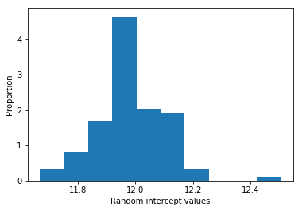

```python
ref_dict = {}
for k, v in mdf.random_effects.items():
    ref_dict[k] = float(v.values)
plt.hist(ref_dict.values(), density=True)
plt.xlabel('Random intercept values')
plt.ylabel('Proportion')
plt.show()
```

Again, this is tending towards normally distributed albeit with some skew.

```python
r_effs = np.array(list(ref_dict.values()))
r_eff_mean = np.mean(r_effs)
mlm_preds_train = exog_train.dot(mdf.fe_params) + clusters_train.map(ref_dict)
mlm_preds_test = exog_test.dot(mdf.fe_params) + clusters_test.map(ref_dict).fillna(r_eff_mean)
```

```python
print("TRAIN) Quick model RMSE of logged response: {:.4f}".format(mean_squared_error(endog_train, mlm_preds_train)))
print("TEST) Quick model RMSE of logged response: {:.4f}".format(mean_squared_error(endog_test, mlm_preds_test)))
```

```
TRAIN) Quick model RMSE of logged response: 0.0142
TEST) Quick model RMSE of logged response: 0.0239
```

Similarly to the mixed effects random forest, there appears to be some overfitting.

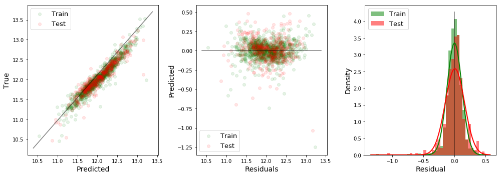

```
TRAIN) Mean of residuals: 0.000
TEST) Mean of residuals: 0.007
```

```python
residual_plots(mlm_preds_train, mlm_preds_test)
```

While the above mixed model performs slightly worse than the base model defined earlier, we are only training on a subset of the predictors. I'm going to refit the base model with the same subset of predictors to see if adding the random effect made any substantial difference.

```python
# Include best predictors from earlier and the grouping variable
tr_array = np.concatenate((Xr_train_std[:, use_cols],
                           full_model_set_train.loc[ir_train, group_col].values.reshape(-1, 1)), axis=1)
ts_array = np.concatenate((Xr_test_std[:, use_cols],
                           full_model_set_train.loc[ir_test, group_col].values.reshape(-1, 1)), axis=1)

endog_limit = yr_train
exog_limit = deepcopy(tr_array)
exog_limit = sm.add_constant(exog_limit, prepend=False)
sm_reg_limit = smf.OLS(endog=endog_limit, exog=exog_limit).fit()
print(sm_reg_limit.summary(xname=use_cols_names + [group_col, 'intercept']))

inpred_train_limit = sm.add_constant(tr_array, prepend=False)
inpred_test_limit = sm.add_constant(ts_array, prepend=False)
sm_reg_preds_train_limit = sm_reg_limit.predict(inpred_train_limit)
sm_reg_preds_test_limit = sm_reg_limit.predict(inpred_test_limit)
print("TRAIN) Quick model RMSE of logged response: {:.4f}".format(mean_squared_error(yr_train, sm_reg_preds_train_limit)))
print("TEST) Quick model RMSE of logged response: {:.4f}".format(mean_squared_error(yr_test, sm_reg_preds_test_limit)))
```

```
                            OLS Regression Results
==============================================================================
Dep. Variable:           LogSalePrice   R-squared:                       0.897
Model:                            OLS   Adj. R-squared:                  0.895
Method:                 Least Squares   F-statistic:                     435.7
Date:                Sun, 30 Jun 2019   Prob (F-statistic):               0.00
Time:                        13:11:47   Log-Likelihood:                 648.82
No. Observations:                1021   AIC:                            -1256.
Df Residuals:                    1000   BIC:                            -1152.
Df Model:                          20
Covariance Type:            nonrobust
========================================================================================
                           coef    std err          t      P>|t|      [0.025      0.975]
----------------------------------------------------------------------------------------
LogLotArea               0.0481      0.006      8.596      0.000       0.037       0.059
OverallQual              0.0901      0.007     12.033      0.000       0.075       0.105
OverallCond              0.0505      0.005     10.592      0.000       0.041       0.060
LogGrLivArea             0.1370      0.006     22.636      0.000       0.125       0.149
GarageCars               0.0469      0.006      8.130      0.000       0.036       0.058
HeatingQC               -0.0256      0.005     -5.102      0.000      -0.035      -0.016
KitchenQual             -0.0266      0.006     -4.284      0.000      -0.039      -0.014
Neighborhood_Edwards    -0.0221      0.004     -5.034      0.000      -0.031      -0.013
Neighborhood_IDOTRR     -0.0237      0.004     -5.522      0.000      -0.032      -0.015
Neighborhood_NridgHt     0.0205      0.005      4.488      0.000       0.012       0.029
Neighborhood_OldTown    -0.0198      0.005     -3.905      0.000      -0.030      -0.010
Condition1_Norm          0.0277      0.004      6.637      0.000       0.020       0.036
BsmtExposure_Gd          0.0271      0.004      6.229      0.000       0.019       0.036
BsmtExposure_None       -0.0230      0.004     -5.410      0.000      -0.031      -0.015
BsmtFinType1_Unf        -0.0354      0.004     -8.099      0.000      -0.044      -0.027
FireplaceQu_None        -0.0227      0.005     -4.693      0.000      -0.032      -0.013
GarageCond_Fa           -0.0091      0.004     -2.124      0.034      -0.017      -0.001
SaleType_New             0.0225      0.005      4.888      0.000       0.013       0.032
MSSubClass_160          -0.0161      0.005     -3.205      0.001      -0.026      -0.006
YearBuilt                0.0022      0.000      8.757      0.000       0.002       0.003
intercept                7.6494      0.499     15.342      0.000       6.671       8.628
==============================================================================
Omnibus:                      441.244   Durbin-Watson:                   1.939
Prob(Omnibus):                  0.000   Jarque-Bera (JB):             6741.700
Skew:                          -1.568   Prob(JB):                         0.00
Kurtosis:                      15.192   Cond. No.                     2.42e+05
==============================================================================

Warnings:
[1] Standard Errors assume that the covariance matrix of the errors is correctly specified.
[2] The condition number is large, 2.42e+05. This might indicate that there are
strong multicollinearity or other numerical problems.
TRAIN) Quick model RMSE of logged response: 0.0164
TEST) Quick model RMSE of logged response: 0.0198
```

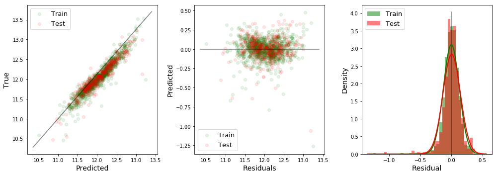

```
TRAIN) Mean of residuals: 0.000
TEST) Mean of residuals: 0.006
```

```python
residual_plots(sm_reg_preds_train_limit, sm_reg_preds_test_limit)
```

In reality, there does not seem to be much difference between when the grouping variable is used as a fixed or a random effect (other than the latter case seeing a smaller training error and larger test error). Perhaps this data is not well suited to this approach. I will prepare a submission regardless so I can see how well it performs on the leaderboard.

```python
final_df = full_model_set_test[all_other_feature_cols].copy()
#final_df['KitchenQual'].replace(' TA', 3, inplace=True)

Xr_final_std = ssr.transform(final_df)
Zr_final = np.ones((Xr_final_std.shape[0], 1))
clusters_final = full_model_set_test.loc[:, group_col]

exog_final = deepcopy(Xr_final_std[:, use_cols])

mlm_preds_test = exog_final.dot(mdf.fe_params) + clusters_final.map(ref_dict).fillna(r_eff_mean)

final_predictions_me = pd.DataFrame({'Id': initial_test['Id'],
                                  'SalePrice': np.exp(mlm_preds_test)})
#final_predictions_me.to_csv(r'data\submissions\submission_me.csv', index=False)
```

The Elastic Net regression performed the best with a final score on a non-public dataset of 0.12724, compared to the mixed linear model's 0.13344.

Return to top Return to main page